# Within-Visit Assay Correlations and Maternal Vaccine-Responder Subgroups

Scot Zens and Anja Saso

2026-07-10

# Purpose

This module answers two families of questions, both anchored to the same maternal/cord/infant serology dataset used by the PTNA, SBA and WT_IgG endpoint analyses and by the `06_prediction_models` module:

**A. Within-subject correlation (Q1-Q5)** of the six assay responses (WHOLE_PTNA, WHOLE_SBA, WHOLE_WT_IgG, PRN_IgG, FIM_IgG, PT_IgG) at each of the five serum draws – **PregEarly** and **MatBirth** (maternal), then **InfMon2**, **InfMon5** and **InfMon9** (infant). The maternal draws carry only the three antigen-specific totals; the full six-assay structure appears at the three infant visits.

**B. Staged responder subgrouping (Q6)** using *two* timepoint sets, defined independently and then linked, so the maternal signal and the infant signal are never conflated:

1. **Stage A - maternal response (up to MatBirth).** Low vs high *maternal* responders to vaccination in pregnancy, from the maternal binding panel at PregEarly + MatBirth.
2. **Stage B - infant chain (baseline -> responses).** Low vs high *infant* responders across InfMon2 -> InfMon5 -> InfMon9, where **InfMon2** is the transplacental baseline (pre-primary) and InfMon5/InfMon9 are the post-priming responses. This set adds the whole-bacterial functional assays, which exist only at infant visits.
3. **Stage C - linkage.** Does maternal responder status carry forward – first into the infant baseline, then into the infant’s own post-vaccination responses? We correlate the two scores, cross-tabulate the two subgroupings, and trace the infant trajectory (InfMon2 -> InfMon5 -> InfMon9) stratified by maternal subgroup. Arm concordance (TdaP vs TT) is tested at each stage.

> **Scale caveat (carried from `cord_to_infmon2_analysis`).** Maternal and cord samples were assayed on different plates/runs from the infant samples, so *cross-timepoint* comparisons require the cross-plate-normalised scale. Every correlation here (Q1-Q5) is computed **within a single timepoint**, so the per-plate offset is a constant that cancels and does **not** bias a within-visit correlation. The staged subgrouping (Q6) likewise standardises every feature to a **within-timepoint rank / z-score** before any cross-visit combination, so the maternal panel, the infant panel and the InfMon2 -> InfMon5 -> InfMon9 trajectory are each on their own per-timepoint scale and the offset never enters.

# Coverage of the six assays at each timepoint

The whole-bacterial functional/binding assays (`WHOLE_PTNA`, `WHOLE_SBA`, `WHOLE_WT_IgG`) are run on infant serum only – PTNA and SBA at InfMon2/5/9, and WT_IgG at those plus CordBlood – so they are absent at the early-pregnancy and at-birth maternal draws by design. The three antigen-specific totals are present throughout. We audit this first so any empty correlation cell is attributable to the assay schedule, not to a coding error.

```r
## status() distinguishes three reasons a cell can be empty:
##   - absent (not in panel)           : feature string not in the data at all
##   - not measured here (by design)   : a WHOLE_* assay at a visit where it is
##                                       not run (maternal draws) -- per config
##   - present                         : reports the n with a finite value
cov_tbl <- lapply(names(wide_by_visit), function(tp) {
  visit <- TIMEPOINTS[[tp]]
  w <- wide_by_visit[[tp]]
  data.frame(
    timepoint = tp,
    assay     = params$assays,
    resolved  = vapply(params$assays, function(a) {
      r <- rf(a); if (is.na(r)) "absent (not in panel)" else r }, character(1)),
    status = vapply(params$assays, function(a) {
      r <- rf(a)
      if (is.na(r))                                   "absent (not in panel)"
      else if (!feature_measured_at(r, visit, WHOLE_MAP)) "not measured here (by design)"
      else                                            "present"
    }, character(1)),
    n_nonmissing = vapply(params$assays, function(a) {
      r <- rf(a)
      if (is.na(r) || !(r %in% names(w))) 0L else sum(is.finite(w[[r]]))
    }, integer(1)),
    row.names = NULL)
}) %>% dplyr::bind_rows()

for (i in seq_len(nrow(cov_tbl)))
  nt_log_manual(nt, "WithinVisitCor", cov_tbl$timepoint[i], cov_tbl$assay[i],
                "assay coverage", n_entered = NA, n_used = cov_tbl$n_nonmissing[i],
                note = cov_tbl$status[i])

knitr::kable(cov_tbl,
  caption = "Table 1. Coverage of the six assays at each serum timepoint. WHOLE_PTNA / WHOLE_SBA are measured only at InfMon2/5/9 and WHOLE_WT_IgG additionally at CordBlood, so all three read 'not measured here (by design)' at the maternal draws.")
```

Table 1. Coverage of the six assays at each serum timepoint. WHOLE_PTNA / WHOLE_SBA are measured only at InfMon2/5/9 and WHOLE_WT_IgG additionally at CordBlood, so all three read ‘not measured here (by design)’ at the maternal draws.

| timepoint | assay | resolved | status | n_nonmissing |
| --- | --- | --- | --- | --- |
| Early pregnancy (maternal) | WHOLE_PTNA | WHOLE_PTNA | not measured here (by design) | 0 |
| Early pregnancy (maternal) | WHOLE_SBA | WHOLE_SBA | not measured here (by design) | 0 |
| Early pregnancy (maternal) | WHOLE_WT_IgG | WHOLE_WT_IgG | not measured here (by design) | 0 |
| Early pregnancy (maternal) | PRN_IgG | PRN_IgG | present | 312 |
| Early pregnancy (maternal) | FIM_IgG | FIM_IgG | present | 312 |
| Early pregnancy (maternal) | PT_IgG | PT_IgG | present | 312 |
| At birth (maternal) | WHOLE_PTNA | WHOLE_PTNA | not measured here (by design) | 0 |
| At birth (maternal) | WHOLE_SBA | WHOLE_SBA | not measured here (by design) | 0 |
| At birth (maternal) | WHOLE_WT_IgG | WHOLE_WT_IgG | not measured here (by design) | 0 |
| At birth (maternal) | PRN_IgG | PRN_IgG | present | 283 |
| At birth (maternal) | FIM_IgG | FIM_IgG | present | 283 |
| At birth (maternal) | PT_IgG | PT_IgG | present | 283 |
| InfMon2 (infant baseline) | WHOLE_PTNA | WHOLE_PTNA | present | 237 |
| InfMon2 (infant baseline) | WHOLE_SBA | WHOLE_SBA | present | 222 |
| InfMon2 (infant baseline) | WHOLE_WT_IgG | WHOLE_WT_IgG | present | 223 |
| InfMon2 (infant baseline) | PRN_IgG | PRN_IgG | present | 287 |
| InfMon2 (infant baseline) | FIM_IgG | FIM_IgG | present | 287 |
| InfMon2 (infant baseline) | PT_IgG | PT_IgG | present | 287 |
| InfMon5 (infant) | WHOLE_PTNA | WHOLE_PTNA | present | 236 |
| InfMon5 (infant) | WHOLE_SBA | WHOLE_SBA | present | 229 |
| InfMon5 (infant) | WHOLE_WT_IgG | WHOLE_WT_IgG | present | 221 |
| InfMon5 (infant) | PRN_IgG | PRN_IgG | present | 281 |
| InfMon5 (infant) | FIM_IgG | FIM_IgG | present | 281 |
| InfMon5 (infant) | PT_IgG | PT_IgG | present | 281 |
| InfMon9 (infant) | WHOLE_PTNA | WHOLE_PTNA | present | 236 |
| InfMon9 (infant) | WHOLE_SBA | WHOLE_SBA | present | 209 |
| InfMon9 (infant) | WHOLE_WT_IgG | WHOLE_WT_IgG | present | 222 |
| InfMon9 (infant) | PRN_IgG | PRN_IgG | present | 306 |
| InfMon9 (infant) | FIM_IgG | FIM_IgG | present | 306 |
| InfMon9 (infant) | PT_IgG | PT_IgG | present | 306 |

# Q1-Q5 - Within-subject correlations at each timepoint

The correlation engine, its long-format flattener, and the heatmap renderer all live in `R/within_visit_helpers.R` (`within_visit_cor()`, `cor_long()`, `plot_cor()`). They use pairwise-complete observations, report the n behind every cell, and BH-adjust p-values across the unique assay pairs.

```r
cor_results        <- list()
cor_strata_results <- list()

if (!is.na(infant_arm_src))
  cat(sprintf("*Infant arm (wP vs aP) resolved from `%s`; used to stratify InfMon5/InfMon9 below.*\n\n",
              infant_arm_src))
```

*Infant arm (wP vs aP) resolved from `data_raw$infant_arm`; used to stratify InfMon5/InfMon9 below.*

```r
for (tp in names(wide_by_visit)) {
  w_tp <- wide_by_visit[[tp]]
  cc   <- within_visit_cor(w_tp, ASSAYS, method = params$cor_method)
  cor_results[[tp]] <- cc

  cat("\n\n## ", tp, "\n\n")
  cat(sprintf("Method: **%s**; pairwise-complete observations; p-values BH-adjusted across the %d unique assay pairs.\n\n",
              cc$method, choose(length(cc$cols), 2)))

  cat("**Correlation coefficients (r) -- all infants:**\n\n")
  print(knitr::kable(round(cc$r, 2), caption = sprintf("r matrix - %s (all infants)", tp)))
  cat("\n\n**Pairwise n behind each cell:**\n\n")
  print(knitr::kable(cc$n, caption = sprintf("n matrix - %s", tp)))
  cat("\n\n")

  plot_cor(cc, sprintf("Within-subject correlation - %s (all infants)", tp), has_ggcorr)
  cat("\n\n")

  ## ---- Q4/Q5: stratify InfMon5 & InfMon9 by infant arm (wP vs aP) ----------
  ## The combined ("all infants") matrix above is always kept; the two arm
  ## matrices and a colour-coded scatter panel are added alongside it.
  if (tp %in% STRATIFY_TPS) {
    w_arm <- attach_infant_arm(w_tp, infant_arm_tbl)
    if (!is.null(infant_arm_tbl) && any(!is.na(w_arm$infant_arm))) {
      sc <- within_visit_cor_strata(w_arm, ASSAYS, "infant_arm",
                                    method = params$cor_method)
      cor_strata_results[[tp]] <- sc

      for (g in names(sc$by)) {
        ng <- sum(!is.na(w_arm$infant_arm) & w_arm$infant_arm == g)
        cat(sprintf("\n\n**Correlation coefficients (r) -- %s infants (n = %d):**\n\n", g, ng))
        print(knitr::kable(round(sc$by[[g]]$r, 2),
              caption = sprintf("r matrix - %s (%s infants)", tp, g)))
        cat("\n\n")
        plot_cor(sc$by[[g]],
                 sprintf("Within-subject correlation - %s (%s)", tp, g), has_ggcorr)
        cat("\n\n")
      }

      cat(sprintf("\n\n**Scatter panel -- %s.** Points are subjects coloured by infant arm; coloured lines are per-arm OLS fits, the dashed black line is the overall (combined) fit. Each facet is annotated with the overall and per-arm Spearman r, matching the matrices above.\n\n", tp))
      cor_scatter_panel(w_arm, ASSAYS, color_col = "infant_arm",
                        method = params$cor_method,
                        title = sprintf("Assay-pair scatter by infant arm - %s", tp))
      cat("\n\n")
    } else {
      cat("\n\n*Infant-arm (wP/aP) stratification skipped: no priming variable was resolved.*\n\n")
    }
  }
}
```

## Early pregnancy (maternal)

Method: **spearman**; pairwise-complete observations; p-values BH-adjusted across the 3 unique assay pairs.

**Correlation coefficients (r) – all infants:**

r matrix - Early pregnancy (maternal) (all infants)

|  | PRN_IgG | FIM_IgG | PT_IgG |
| --- | --- | --- | --- |
| PRN_IgG | 1.00 | 0.38 | 0.46 |
| FIM_IgG | 0.38 | 1.00 | 0.32 |
| PT_IgG | 0.46 | 0.32 | 1.00 |

**Pairwise n behind each cell:**

n matrix - Early pregnancy (maternal)

|  | PRN_IgG | FIM_IgG | PT_IgG |
| --- | --- | --- | --- |
| PRN_IgG | 312 | 312 | 312 |
| FIM_IgG | 312 | 312 | 312 |
| PT_IgG | 312 | 312 | 312 |

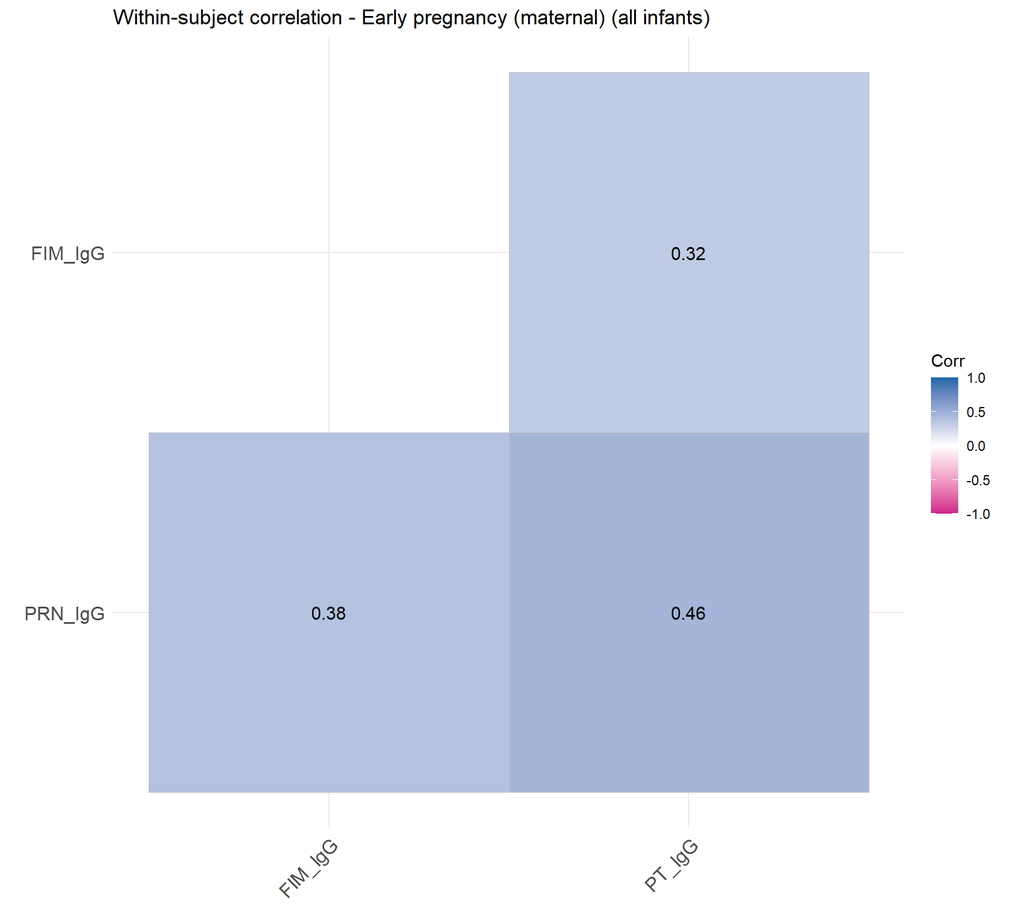

## At birth (maternal)

Method: **spearman**; pairwise-complete observations; p-values BH-adjusted across the 3 unique assay pairs.

**Correlation coefficients (r) – all infants:**

r matrix - At birth (maternal) (all infants)

|  | PRN_IgG | FIM_IgG | PT_IgG |
| --- | --- | --- | --- |
| PRN_IgG | 1.00 | 0.27 | 0.77 |
| FIM_IgG | 0.27 | 1.00 | 0.25 |
| PT_IgG | 0.77 | 0.25 | 1.00 |

**Pairwise n behind each cell:**

n matrix - At birth (maternal)

|  | PRN_IgG | FIM_IgG | PT_IgG |
| --- | --- | --- | --- |
| PRN_IgG | 283 | 283 | 283 |
| FIM_IgG | 283 | 283 | 283 |
| PT_IgG | 283 | 283 | 283 |

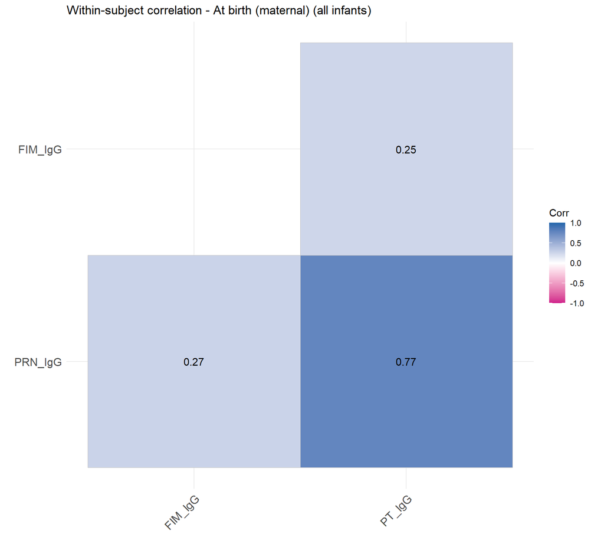

## InfMon2 (infant baseline)

Method: **spearman**; pairwise-complete observations; p-values BH-adjusted across the 15 unique assay pairs.

**Correlation coefficients (r) – all infants:**

r matrix - InfMon2 (infant baseline) (all infants)

|  | WHOLE_PTNA | WHOLE_SBA | WHOLE_WT_IgG | PRN_IgG | FIM_IgG | PT_IgG |
| --- | --- | --- | --- | --- | --- | --- |
| WHOLE_PTNA | 1.00 | 0.48 | 0.38 | 0.56 | 0.11 | 0.74 |
| WHOLE_SBA | 0.48 | 1.00 | 0.69 | 0.84 | 0.25 | 0.64 |
| WHOLE_WT_IgG | 0.38 | 0.69 | 1.00 | 0.65 | 0.22 | 0.51 |
| PRN_IgG | 0.56 | 0.84 | 0.65 | 1.00 | 0.27 | 0.77 |
| FIM_IgG | 0.11 | 0.25 | 0.22 | 0.27 | 1.00 | 0.23 |
| PT_IgG | 0.74 | 0.64 | 0.51 | 0.77 | 0.23 | 1.00 |

**Pairwise n behind each cell:**

n matrix - InfMon2 (infant baseline)

|  | WHOLE_PTNA | WHOLE_SBA | WHOLE_WT_IgG | PRN_IgG | FIM_IgG | PT_IgG |
| --- | --- | --- | --- | --- | --- | --- |
| WHOLE_PTNA | 237 | 220 | 221 | 237 | 237 | 237 |
| WHOLE_SBA | 220 | 222 | 206 | 222 | 222 | 222 |
| WHOLE_WT_IgG | 221 | 206 | 223 | 223 | 223 | 223 |
| PRN_IgG | 237 | 222 | 223 | 287 | 287 | 287 |
| FIM_IgG | 237 | 222 | 223 | 287 | 287 | 287 |
| PT_IgG | 237 | 222 | 223 | 287 | 287 | 287 |

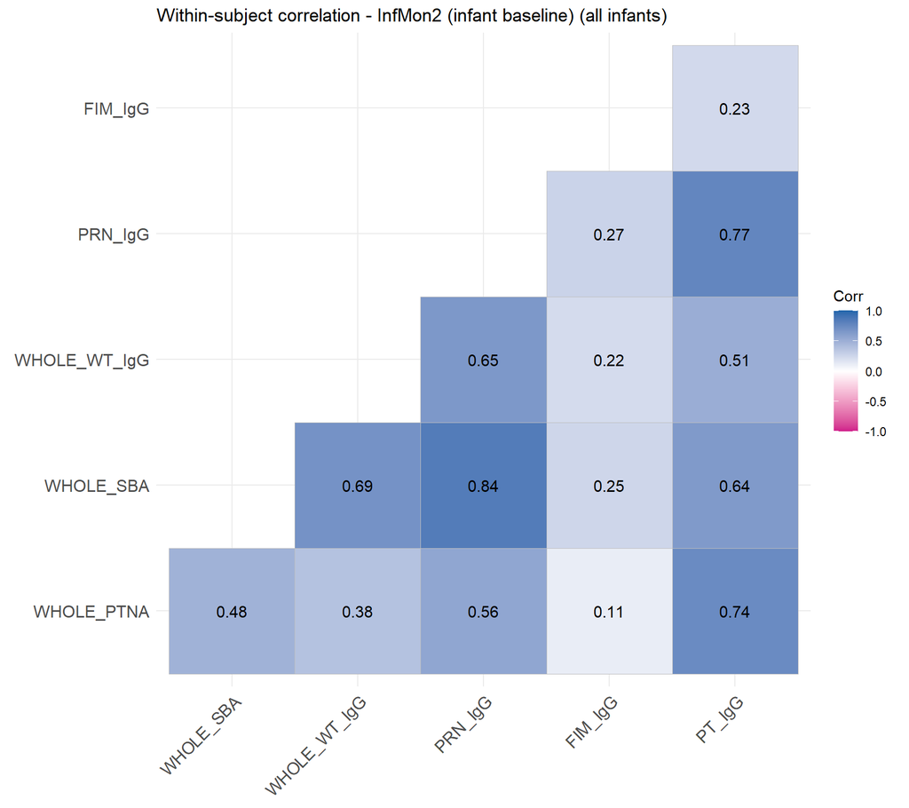

## InfMon5 (infant)

Method: **spearman**; pairwise-complete observations; p-values BH-adjusted across the 15 unique assay pairs.

**Correlation coefficients (r) – all infants:**

r matrix - InfMon5 (infant) (all infants)

|  | WHOLE_PTNA | WHOLE_SBA | WHOLE_WT_IgG | PRN_IgG | FIM_IgG | PT_IgG |
| --- | --- | --- | --- | --- | --- | --- |
| WHOLE_PTNA | 1.00 | 0.14 | 0.16 | 0.13 | 0.10 | 0.56 |
| WHOLE_SBA | 0.14 | 1.00 | 0.42 | 0.30 | 0.35 | 0.13 |
| WHOLE_WT_IgG | 0.16 | 0.42 | 1.00 | 0.17 | 0.23 | 0.09 |
| PRN_IgG | 0.13 | 0.30 | 0.17 | 1.00 | -0.28 | 0.33 |
| FIM_IgG | 0.10 | 0.35 | 0.23 | -0.28 | 1.00 | -0.02 |
| PT_IgG | 0.56 | 0.13 | 0.09 | 0.33 | -0.02 | 1.00 |

**Pairwise n behind each cell:**

n matrix - InfMon5 (infant)

|  | WHOLE_PTNA | WHOLE_SBA | WHOLE_WT_IgG | PRN_IgG | FIM_IgG | PT_IgG |
| --- | --- | --- | --- | --- | --- | --- |
| WHOLE_PTNA | 236 | 227 | 219 | 236 | 236 | 236 |
| WHOLE_SBA | 227 | 229 | 210 | 229 | 229 | 229 |
| WHOLE_WT_IgG | 219 | 210 | 221 | 221 | 221 | 221 |
| PRN_IgG | 236 | 229 | 221 | 281 | 281 | 281 |
| FIM_IgG | 236 | 229 | 221 | 281 | 281 | 281 |
| PT_IgG | 236 | 229 | 221 | 281 | 281 | 281 |

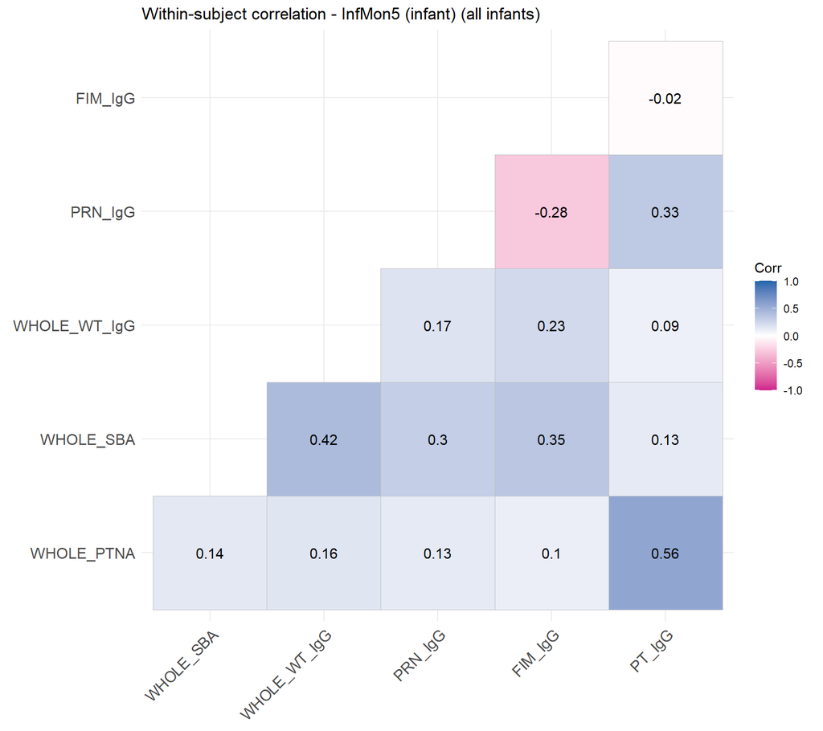

**Correlation coefficients (r) – wP infants (n = 151):**

r matrix - InfMon5 (infant) (wP infants)

|  | WHOLE_PTNA | WHOLE_SBA | WHOLE_WT_IgG | PRN_IgG | FIM_IgG | PT_IgG |
| --- | --- | --- | --- | --- | --- | --- |
| WHOLE_PTNA | 1.00 | 0.06 | 0.16 | 0.03 | 0.24 | 0.68 |
| WHOLE_SBA | 0.06 | 1.00 | 0.34 | 0.50 | 0.27 | 0.24 |
| WHOLE_WT_IgG | 0.16 | 0.34 | 1.00 | 0.29 | 0.23 | 0.17 |
| PRN_IgG | 0.03 | 0.50 | 0.29 | 1.00 | 0.23 | 0.18 |
| FIM_IgG | 0.24 | 0.27 | 0.23 | 0.23 | 1.00 | 0.35 |
| PT_IgG | 0.68 | 0.24 | 0.17 | 0.18 | 0.35 | 1.00 |

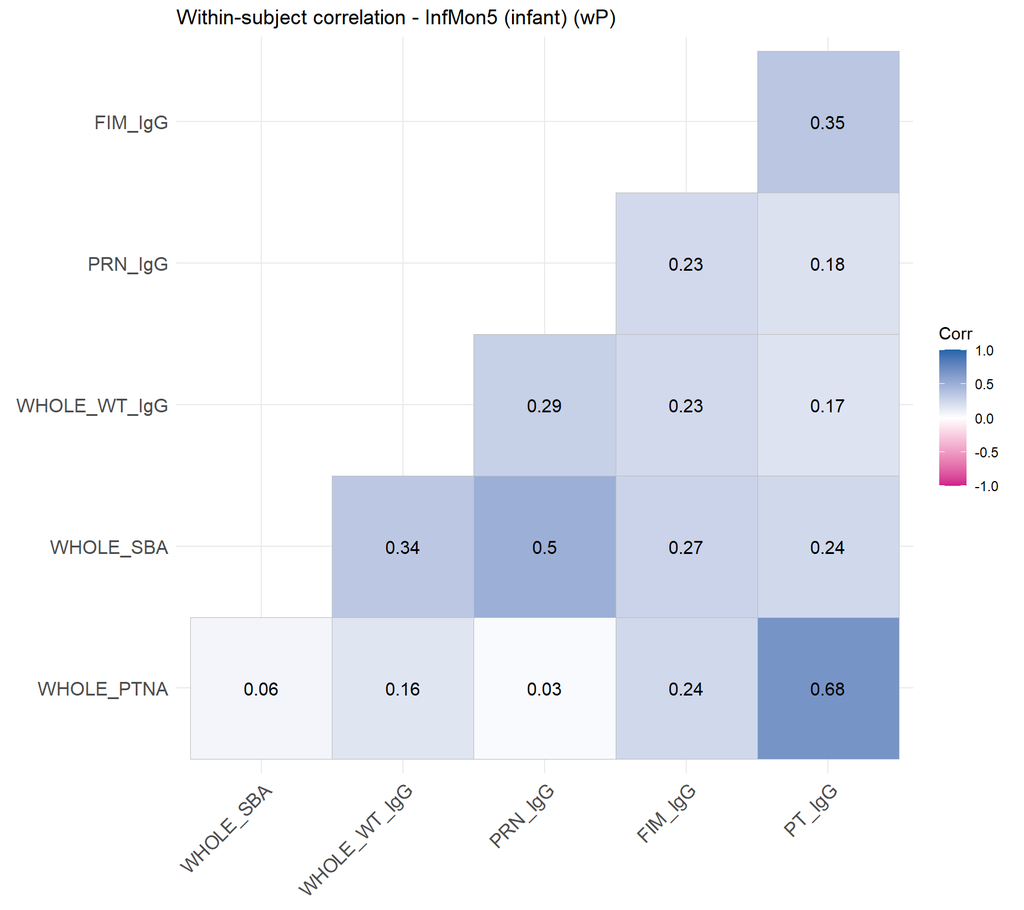

**Correlation coefficients (r) – aP infants (n = 130):**

r matrix - InfMon5 (infant) (aP infants)

|  | WHOLE_PTNA | WHOLE_SBA | WHOLE_WT_IgG | PRN_IgG | FIM_IgG | PT_IgG |
| --- | --- | --- | --- | --- | --- | --- |
| WHOLE_PTNA | 1.00 | 0.21 | 0.13 | 0.30 | 0.01 | 0.40 |
| WHOLE_SBA | 0.21 | 1.00 | 0.38 | 0.67 | -0.16 | 0.15 |
| WHOLE_WT_IgG | 0.13 | 0.38 | 1.00 | 0.33 | -0.14 | 0.12 |
| PRN_IgG | 0.30 | 0.67 | 0.33 | 1.00 | -0.07 | 0.45 |
| FIM_IgG | 0.01 | -0.16 | -0.14 | -0.07 | 1.00 | 0.04 |
| PT_IgG | 0.40 | 0.15 | 0.12 | 0.45 | 0.04 | 1.00 |

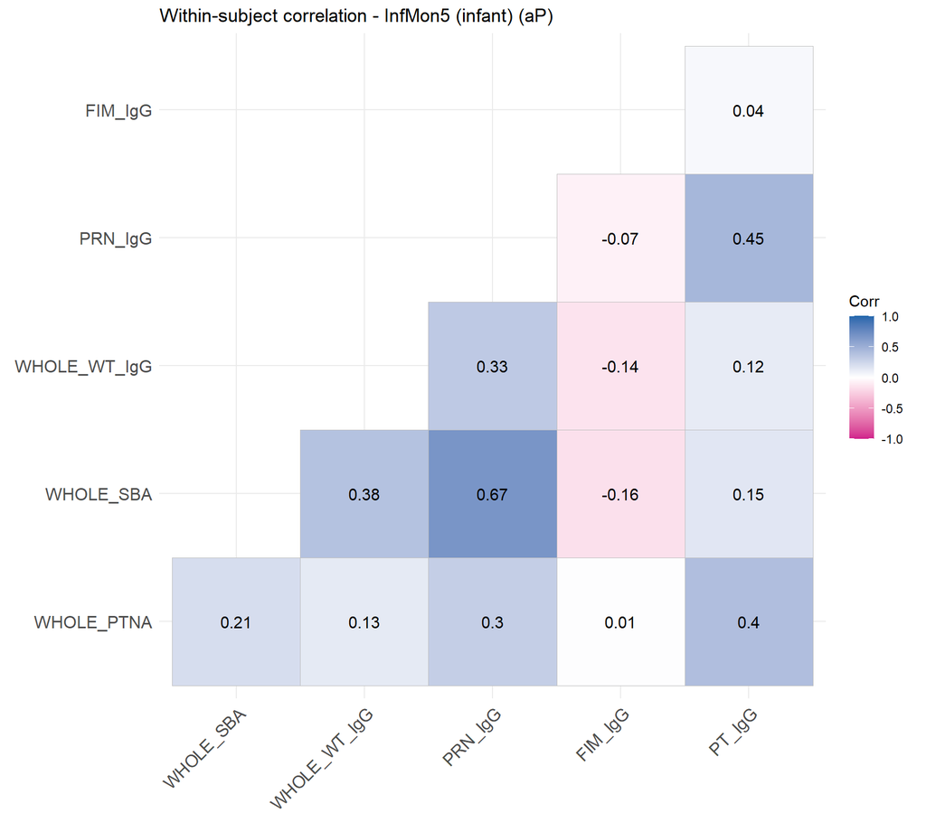

**Scatter panel – InfMon5 (infant).** Points are subjects coloured by infant arm; coloured lines are per-arm OLS fits, the dashed black line is the overall (combined) fit. Each facet is annotated with the overall and per-arm Spearman r, matching the matrices above.

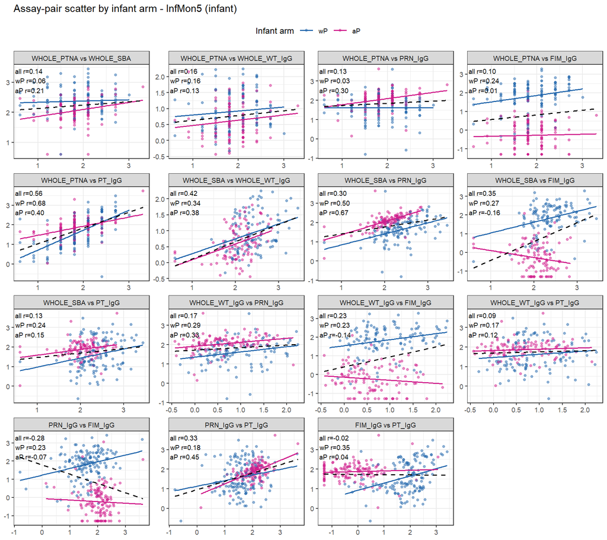

## InfMon9 (infant)

Method: **spearman**; pairwise-complete observations; p-values BH-adjusted across the 15 unique assay pairs.

**Correlation coefficients (r) – all infants:**

r matrix - InfMon9 (infant) (all infants)

|  | WHOLE_PTNA | WHOLE_SBA | WHOLE_WT_IgG | PRN_IgG | FIM_IgG | PT_IgG |
| --- | --- | --- | --- | --- | --- | --- |
| WHOLE_PTNA | 1.00 | 0.33 | 0.21 | 0.20 | 0.13 | 0.66 |
| WHOLE_SBA | 0.33 | 1.00 | 0.46 | 0.50 | 0.36 | 0.38 |
| WHOLE_WT_IgG | 0.21 | 0.46 | 1.00 | 0.29 | 0.20 | 0.12 |
| PRN_IgG | 0.20 | 0.50 | 0.29 | 1.00 | -0.21 | 0.38 |
| FIM_IgG | 0.13 | 0.36 | 0.20 | -0.21 | 1.00 | 0.12 |
| PT_IgG | 0.66 | 0.38 | 0.12 | 0.38 | 0.12 | 1.00 |

**Pairwise n behind each cell:**

n matrix - InfMon9 (infant)

|  | WHOLE_PTNA | WHOLE_SBA | WHOLE_WT_IgG | PRN_IgG | FIM_IgG | PT_IgG |
| --- | --- | --- | --- | --- | --- | --- |
| WHOLE_PTNA | 236 | 209 | 220 | 236 | 236 | 236 |
| WHOLE_SBA | 209 | 209 | 196 | 209 | 209 | 209 |
| WHOLE_WT_IgG | 220 | 196 | 222 | 222 | 222 | 222 |
| PRN_IgG | 236 | 209 | 222 | 306 | 306 | 306 |
| FIM_IgG | 236 | 209 | 222 | 306 | 306 | 306 |
| PT_IgG | 236 | 209 | 222 | 306 | 306 | 306 |

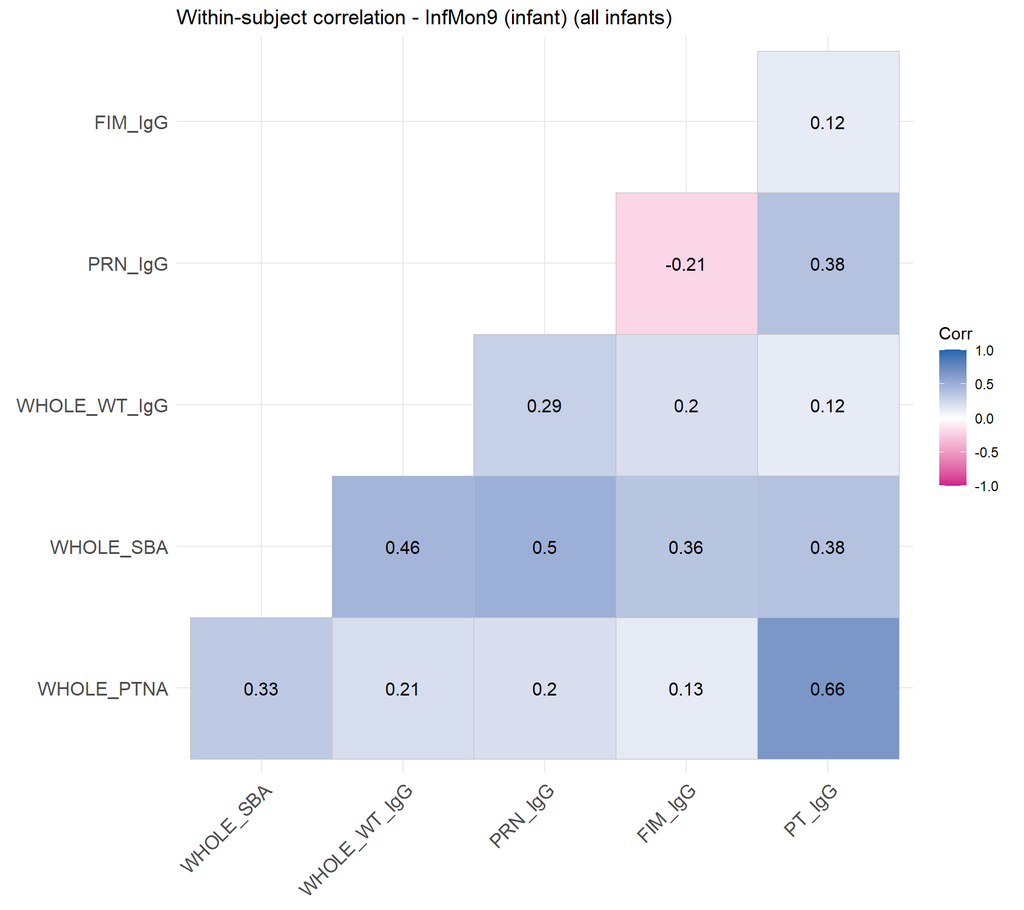

**Correlation coefficients (r) – wP infants (n = 155):**

r matrix - InfMon9 (infant) (wP infants)

|  | WHOLE_PTNA | WHOLE_SBA | WHOLE_WT_IgG | PRN_IgG | FIM_IgG | PT_IgG |
| --- | --- | --- | --- | --- | --- | --- |
| WHOLE_PTNA | 1.00 | 0.39 | 0.29 | 0.24 | 0.29 | 0.75 |
| WHOLE_SBA | 0.39 | 1.00 | 0.47 | 0.60 | 0.39 | 0.49 |
| WHOLE_WT_IgG | 0.29 | 0.47 | 1.00 | 0.38 | 0.24 | 0.19 |
| PRN_IgG | 0.24 | 0.60 | 0.38 | 1.00 | 0.33 | 0.38 |
| FIM_IgG | 0.29 | 0.39 | 0.24 | 0.33 | 1.00 | 0.40 |
| PT_IgG | 0.75 | 0.49 | 0.19 | 0.38 | 0.40 | 1.00 |

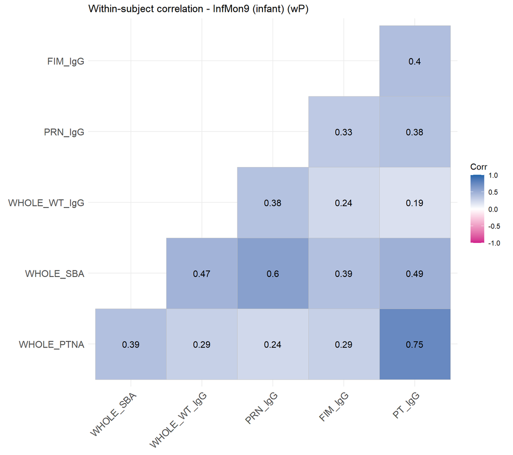

**Correlation coefficients (r) – aP infants (n = 152):**

r matrix - InfMon9 (infant) (aP infants)

|  | WHOLE_PTNA | WHOLE_SBA | WHOLE_WT_IgG | PRN_IgG | FIM_IgG | PT_IgG |
| --- | --- | --- | --- | --- | --- | --- |
| WHOLE_PTNA | 1.00 | 0.27 | 0.07 | 0.22 | 0.00 | 0.45 |
| WHOLE_SBA | 0.27 | 1.00 | 0.43 | 0.70 | 0.19 | 0.18 |
| WHOLE_WT_IgG | 0.07 | 0.43 | 1.00 | 0.38 | 0.14 | -0.02 |
| PRN_IgG | 0.22 | 0.70 | 0.38 | 1.00 | -0.04 | 0.37 |
| FIM_IgG | 0.00 | 0.19 | 0.14 | -0.04 | 1.00 | 0.02 |
| PT_IgG | 0.45 | 0.18 | -0.02 | 0.37 | 0.02 | 1.00 |

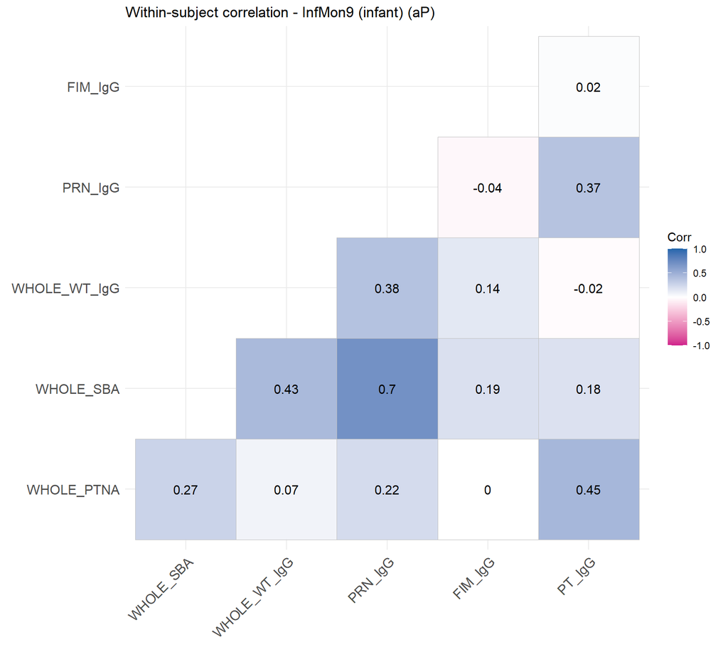

**Scatter panel – InfMon9 (infant).** Points are subjects coloured by infant arm; coloured lines are per-arm OLS fits, the dashed black line is the overall (combined) fit. Each facet is annotated with the overall and per-arm Spearman r, matching the matrices above.

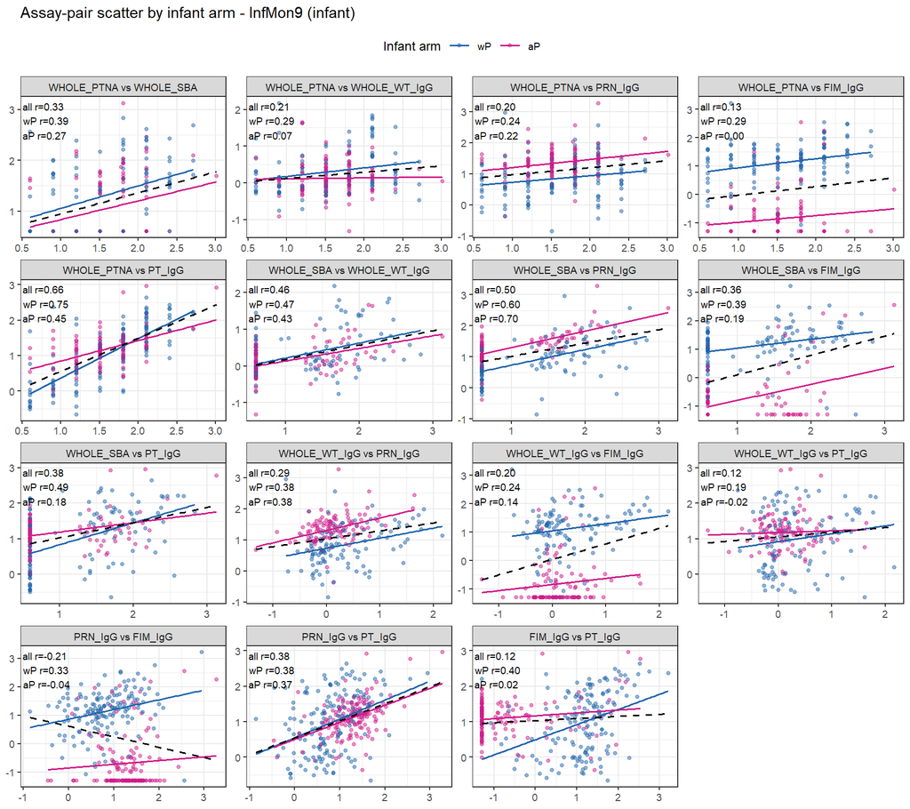

```r
## tidy long table across all timepoints (for the summary engine / Word reader)
cor_all <- dplyr::bind_rows(lapply(names(cor_results),
                                   function(tp) cor_long(cor_results[[tp]], tp)))
```

```r
disp <- cor_all %>%
  mutate(r = round(r, 3), p = signif(p, 3), p_BH = signif(p_BH, 3),
         sig = cut(p_BH, c(-Inf, .001, .01, .05, .1, Inf),
                   labels = c("***", "**", "*", ".", ""))) %>%
  arrange(timepoint, desc(abs(r)))
knitr::kable(disp,
  caption = "Table 2. All within-subject assay-pair correlations at each timepoint (sorted by |r| within timepoint).")
```

Table 2. All within-subject assay-pair correlations at each timepoint (sorted by |r| within timepoint).

| timepoint | assay_x | assay_y | r | n | p | p_BH | sig |
| --- | --- | --- | --- | --- | --- | --- | --- |
| At birth (maternal) | PRN_IgG | PT_IgG | 0.769 | 283 | 0.00e+00 | 0.00e+00 | *** |
| At birth (maternal) | PRN_IgG | FIM_IgG | 0.273 | 283 | 3.10e-06 | 4.70e-06 | *** |
| At birth (maternal) | FIM_IgG | PT_IgG | 0.246 | 283 | 2.80e-05 | 2.80e-05 | *** |
| Early pregnancy (maternal) | PRN_IgG | PT_IgG | 0.462 | 312 | 0.00e+00 | 0.00e+00 | *** |
| Early pregnancy (maternal) | PRN_IgG | FIM_IgG | 0.377 | 312 | 0.00e+00 | 0.00e+00 | *** |
| Early pregnancy (maternal) | FIM_IgG | PT_IgG | 0.318 | 312 | 0.00e+00 | 0.00e+00 | *** |
| InfMon2 (infant baseline) | WHOLE_SBA | PRN_IgG | 0.841 | 222 | 0.00e+00 | 0.00e+00 | *** |
| InfMon2 (infant baseline) | PRN_IgG | PT_IgG | 0.775 | 287 | 0.00e+00 | 0.00e+00 | *** |
| InfMon2 (infant baseline) | WHOLE_PTNA | PT_IgG | 0.743 | 237 | 0.00e+00 | 0.00e+00 | *** |
| InfMon2 (infant baseline) | WHOLE_SBA | WHOLE_WT_IgG | 0.688 | 206 | 0.00e+00 | 0.00e+00 | *** |
| InfMon2 (infant baseline) | WHOLE_WT_IgG | PRN_IgG | 0.647 | 223 | 0.00e+00 | 0.00e+00 | *** |
| InfMon2 (infant baseline) | WHOLE_SBA | PT_IgG | 0.643 | 222 | 0.00e+00 | 0.00e+00 | *** |
| InfMon2 (infant baseline) | WHOLE_PTNA | PRN_IgG | 0.564 | 237 | 0.00e+00 | 0.00e+00 | *** |
| InfMon2 (infant baseline) | WHOLE_WT_IgG | PT_IgG | 0.510 | 223 | 0.00e+00 | 0.00e+00 | *** |
| InfMon2 (infant baseline) | WHOLE_PTNA | WHOLE_SBA | 0.477 | 220 | 0.00e+00 | 0.00e+00 | *** |
| InfMon2 (infant baseline) | WHOLE_PTNA | WHOLE_WT_IgG | 0.376 | 221 | 0.00e+00 | 0.00e+00 | *** |
| InfMon2 (infant baseline) | PRN_IgG | FIM_IgG | 0.267 | 287 | 4.50e-06 | 6.10e-06 | *** |
| InfMon2 (infant baseline) | WHOLE_SBA | FIM_IgG | 0.251 | 222 | 1.56e-04 | 1.80e-04 | *** |
| InfMon2 (infant baseline) | FIM_IgG | PT_IgG | 0.231 | 287 | 7.88e-05 | 9.85e-05 | *** |
| InfMon2 (infant baseline) | WHOLE_WT_IgG | FIM_IgG | 0.222 | 223 | 8.39e-04 | 8.99e-04 | *** |
| InfMon2 (infant baseline) | WHOLE_PTNA | FIM_IgG | 0.114 | 237 | 8.08e-02 | 8.08e-02 | . |
| InfMon5 (infant) | WHOLE_PTNA | PT_IgG | 0.561 | 236 | 0.00e+00 | 0.00e+00 | *** |
| InfMon5 (infant) | WHOLE_SBA | WHOLE_WT_IgG | 0.420 | 210 | 0.00e+00 | 0.00e+00 | *** |
| InfMon5 (infant) | WHOLE_SBA | FIM_IgG | 0.346 | 229 | 1.00e-07 | 3.00e-07 | *** |
| InfMon5 (infant) | PRN_IgG | PT_IgG | 0.331 | 281 | 0.00e+00 | 1.00e-07 | *** |
| InfMon5 (infant) | WHOLE_SBA | PRN_IgG | 0.297 | 229 | 5.00e-06 | 1.24e-05 | *** |
| InfMon5 (infant) | PRN_IgG | FIM_IgG | -0.278 | 281 | 2.30e-06 | 6.80e-06 | *** |
| InfMon5 (infant) | WHOLE_WT_IgG | FIM_IgG | 0.235 | 221 | 4.28e-04 | 9.17e-04 | *** |
| InfMon5 (infant) | WHOLE_WT_IgG | PRN_IgG | 0.173 | 221 | 1.01e-02 | 1.89e-02 | * |
| InfMon5 (infant) | WHOLE_PTNA | WHOLE_WT_IgG | 0.162 | 219 | 1.67e-02 | 2.78e-02 | * |
| InfMon5 (infant) | WHOLE_PTNA | WHOLE_SBA | 0.136 | 227 | 3.99e-02 | 5.99e-02 | . |
| InfMon5 (infant) | WHOLE_SBA | PT_IgG | 0.130 | 229 | 4.89e-02 | 6.42e-02 | . |
| InfMon5 (infant) | WHOLE_PTNA | PRN_IgG | 0.127 | 236 | 5.13e-02 | 6.42e-02 | . |
| InfMon5 (infant) | WHOLE_PTNA | FIM_IgG | 0.098 | 236 | 1.34e-01 | 1.55e-01 |  |
| InfMon5 (infant) | WHOLE_WT_IgG | PT_IgG | 0.092 | 221 | 1.73e-01 | 1.85e-01 |  |
| InfMon5 (infant) | FIM_IgG | PT_IgG | -0.018 | 281 | 7.68e-01 | 7.68e-01 |  |
| InfMon9 (infant) | WHOLE_PTNA | PT_IgG | 0.657 | 236 | 0.00e+00 | 0.00e+00 | *** |
| InfMon9 (infant) | WHOLE_SBA | PRN_IgG | 0.500 | 209 | 0.00e+00 | 0.00e+00 | *** |
| InfMon9 (infant) | WHOLE_SBA | WHOLE_WT_IgG | 0.459 | 196 | 0.00e+00 | 0.00e+00 | *** |
| InfMon9 (infant) | PRN_IgG | PT_IgG | 0.381 | 306 | 0.00e+00 | 0.00e+00 | *** |
| InfMon9 (infant) | WHOLE_SBA | PT_IgG | 0.377 | 209 | 0.00e+00 | 1.00e-07 | *** |
| InfMon9 (infant) | WHOLE_SBA | FIM_IgG | 0.362 | 209 | 1.00e-07 | 2.00e-07 | *** |
| InfMon9 (infant) | WHOLE_PTNA | WHOLE_SBA | 0.333 | 209 | 8.00e-07 | 1.80e-06 | *** |
| InfMon9 (infant) | WHOLE_WT_IgG | PRN_IgG | 0.285 | 222 | 1.57e-05 | 2.94e-05 | *** |
| InfMon9 (infant) | PRN_IgG | FIM_IgG | -0.209 | 306 | 2.36e-04 | 3.94e-04 | *** |
| InfMon9 (infant) | WHOLE_PTNA | WHOLE_WT_IgG | 0.208 | 220 | 1.95e-03 | 2.93e-03 | ** |
| InfMon9 (infant) | WHOLE_PTNA | PRN_IgG | 0.196 | 236 | 2.54e-03 | 3.47e-03 | ** |
| InfMon9 (infant) | WHOLE_WT_IgG | FIM_IgG | 0.196 | 222 | 3.44e-03 | 4.30e-03 | ** |
| InfMon9 (infant) | WHOLE_PTNA | FIM_IgG | 0.132 | 236 | 4.34e-02 | 4.65e-02 | * |
| InfMon9 (infant) | FIM_IgG | PT_IgG | 0.121 | 306 | 3.39e-02 | 3.91e-02 | * |
| InfMon9 (infant) | WHOLE_WT_IgG | PT_IgG | 0.115 | 222 | 8.70e-02 | 8.70e-02 | . |

```r
## Table 2b: InfMon5/InfMon9 correlations, overall vs stratified by infant arm.
if (length(cor_strata_results)) {
  strata_all <- dplyr::bind_rows(lapply(names(cor_strata_results),
    function(tp) cor_strata_long(cor_strata_results[[tp]], tp)))
  disp_s <- strata_all %>%
    mutate(r = round(r, 3), p = signif(p, 3), p_BH = signif(p_BH, 3),
           sig = cut(p_BH, c(-Inf, .001, .01, .05, .1, Inf),
                     labels = c("***", "**", "*", ".", ""))) %>%
    arrange(timepoint, assay_x, assay_y,
            factor(stratum, levels = c("all", "wP", "aP")))
  print(knitr::kable(disp_s,
    caption = paste0("Table 2b. InfMon5 / InfMon9 within-subject correlations, ",
                     "overall ('all') and stratified by infant arm (wP / aP). ",
                     "BH adjustment is within each (timepoint x stratum) pair set.")))
} else {
  cat("*No infant-arm-stratified correlations were produced ",
      "(no priming variable resolved).*\n\n")
}
```

Table 2b. InfMon5 / InfMon9 within-subject correlations, overall (‘all’) and stratified by infant arm (wP / aP). BH adjustment is within each (timepoint x stratum) pair set.

| timepoint | assay_x | assay_y | r | n | p | p_BH | stratum | sig |
| --- | --- | --- | --- | --- | --- | --- | --- | --- |
| InfMon5 (infant) | FIM_IgG | PT_IgG | -0.018 | 281 | 7.68e-01 | 7.68e-01 | all |  |
| InfMon5 (infant) | FIM_IgG | PT_IgG | 0.354 | 151 | 8.10e-06 | 4.07e-05 | wP | *** |
| InfMon5 (infant) | FIM_IgG | PT_IgG | 0.038 | 130 | 6.69e-01 | 7.17e-01 | aP |  |
| InfMon5 (infant) | PRN_IgG | FIM_IgG | -0.278 | 281 | 2.30e-06 | 6.80e-06 | all | *** |
| InfMon5 (infant) | PRN_IgG | FIM_IgG | 0.233 | 151 | 3.91e-03 | 8.39e-03 | wP | ** |
| InfMon5 (infant) | PRN_IgG | FIM_IgG | -0.074 | 130 | 4.06e-01 | 4.68e-01 | aP |  |
| InfMon5 (infant) | PRN_IgG | PT_IgG | 0.331 | 281 | 0.00e+00 | 1.00e-07 | all | *** |
| InfMon5 (infant) | PRN_IgG | PT_IgG | 0.183 | 151 | 2.44e-02 | 3.33e-02 | wP | * |
| InfMon5 (infant) | PRN_IgG | PT_IgG | 0.448 | 130 | 1.00e-07 | 7.00e-07 | aP | *** |
| InfMon5 (infant) | WHOLE_PTNA | FIM_IgG | 0.098 | 236 | 1.34e-01 | 1.55e-01 | all |  |
| InfMon5 (infant) | WHOLE_PTNA | FIM_IgG | 0.240 | 120 | 8.41e-03 | 1.56e-02 | wP | * |
| InfMon5 (infant) | WHOLE_PTNA | FIM_IgG | 0.009 | 116 | 9.20e-01 | 9.20e-01 | aP |  |
| InfMon5 (infant) | WHOLE_PTNA | PRN_IgG | 0.127 | 236 | 5.13e-02 | 6.42e-02 | all | . |
| InfMon5 (infant) | WHOLE_PTNA | PRN_IgG | 0.026 | 120 | 7.75e-01 | 7.75e-01 | wP |  |
| InfMon5 (infant) | WHOLE_PTNA | PRN_IgG | 0.298 | 116 | 1.15e-03 | 2.87e-03 | aP | ** |
| InfMon5 (infant) | WHOLE_PTNA | PT_IgG | 0.561 | 236 | 0.00e+00 | 0.00e+00 | all | *** |
| InfMon5 (infant) | WHOLE_PTNA | PT_IgG | 0.684 | 120 | 0.00e+00 | 0.00e+00 | wP | *** |
| InfMon5 (infant) | WHOLE_PTNA | PT_IgG | 0.403 | 116 | 7.30e-06 | 3.64e-05 | aP | *** |
| InfMon5 (infant) | WHOLE_PTNA | WHOLE_SBA | 0.136 | 227 | 3.99e-02 | 5.99e-02 | all | . |
| InfMon5 (infant) | WHOLE_PTNA | WHOLE_SBA | 0.062 | 119 | 5.01e-01 | 5.37e-01 | wP |  |
| InfMon5 (infant) | WHOLE_PTNA | WHOLE_SBA | 0.210 | 108 | 2.91e-02 | 6.23e-02 | aP | . |
| InfMon5 (infant) | WHOLE_PTNA | WHOLE_WT_IgG | 0.162 | 219 | 1.67e-02 | 2.78e-02 | all | * |
| InfMon5 (infant) | WHOLE_PTNA | WHOLE_WT_IgG | 0.159 | 111 | 9.60e-02 | 1.11e-01 | wP |  |
| InfMon5 (infant) | WHOLE_PTNA | WHOLE_WT_IgG | 0.127 | 108 | 1.91e-01 | 2.61e-01 | aP |  |
| InfMon5 (infant) | WHOLE_SBA | FIM_IgG | 0.346 | 229 | 1.00e-07 | 3.00e-07 | all | *** |
| InfMon5 (infant) | WHOLE_SBA | FIM_IgG | 0.269 | 119 | 3.10e-03 | 7.75e-03 | wP | ** |
| InfMon5 (infant) | WHOLE_SBA | FIM_IgG | -0.165 | 110 | 8.50e-02 | 1.59e-01 | aP |  |
| InfMon5 (infant) | WHOLE_SBA | PRN_IgG | 0.297 | 229 | 5.00e-06 | 1.24e-05 | all | *** |
| InfMon5 (infant) | WHOLE_SBA | PRN_IgG | 0.503 | 119 | 0.00e+00 | 0.00e+00 | wP | *** |
| InfMon5 (infant) | WHOLE_SBA | PRN_IgG | 0.675 | 110 | 0.00e+00 | 0.00e+00 | aP | *** |

[output cut: 60 more lines]

## How Q1-Q5 should be read

- **Stability of the correlation structure across timepoints** tells you whether the six assays measure a single shared “magnitude” axis (all strongly positively correlated) or several semi-independent axes. A pertussis cluster (`WHOLE_PTNA`, `PT_IgG`, and possibly `WHOLE_WT_IgG`) that is tighter than its correlation with `FIM_IgG`/`SBA` would indicate antigen-specific structure rather than a single global responder magnitude.
- **Why a within-subject correlation is the right object here.** Each row is one subject measured on one draw; correlating the columns asks “do subjects who are high on assay A tend to be high on assay B *on the same sample*?” This is exactly the input the staged responder-subgrouping step (Q6) needs.
- The **maternal** matrices (Q1, Q2) necessarily contain only the three antigen-specific totals (`PT_IgG`, `PRN_IgG`, `FIM_IgG`); the whole-bacterial assays are not measured on maternal serum (Table 1). The full six-assay structure is observable at **InfMon2, InfMon5 and InfMon9** (Q3-Q5), letting you watch the structure evolve from the pre-primary baseline through the infant’s own vaccine responses.

# Q6 - Staged responder subgroups: maternal -> infant baseline -> infant responses

## Strategy

We separate the **maternal** response from the **infant** response by building two independent panels, then linking them, so the two signals are never conflated:

- **Stage A (maternal response, up to MatBirth).** Binding panel (PT_IgG, FHA_IgG, PRN_IgG) at PregEarly + MatBirth. No whole-bacterial assays exist on maternal serum, so the maternal responder is defined on antigen-specific binding alone. MatBirth is the post-vaccination state; PregEarly the pre-vaccination baseline.
- **Stage B (infant chain).** The same binding panel **plus** the whole-bacterial functional assays (WHOLE_SBA, WHOLE_WT_IgG) across InfMon2 -> InfMon5 -> InfMon9. InfMon2 is the transplacental baseline (what the mother supplied); InfMon5/InfMon9 are the infant’s own post-priming responses.
- **Stage C (linkage).** Correlate the maternal and infant scores, cross-tabulate the two subgroupings, and trace the infant score across the three infant visits **stratified by maternal subgroup** – reading left to right is exactly “maternal response -> infant baseline -> infant responses”.

Each feature is converted to a within-timepoint **Blom z-score** (so the cross-plate offset cancels), the **responder score** is the subject mean z over its panel, and a **breadth** metric separates uniformly high/low (universal) from spiky subjects. Subgroups come from PAM clustering with silhouette-chosen k, with a transparent tertile rule as the fallback/sensitivity check. The reusable engine lives in `build_responder_panel()`, `summarise_responder_subjects()`, `add_tertile_bands()`, `build_resp_wide()`, `detect_subgroups()` and `responder_score_by_visit()`.

## Stage A - Maternal responder subgroups (up to MatBirth)

```r
cat(sprintf("Maternal panel: features **%s** at **%s** (binding only -- no whole-bacterial on maternal serum).\n\n",
            paste(RESP_FEATS, collapse = ", "), paste(MAT_VIS, collapse = ", ")))
```

Maternal panel: features **PT_IgG, FHA_IgG, PRN_IgG** at **PregEarly, MatBirth** (binding only – no whole-bacterial on maternal serum).

```r
print(knitr::kable(
  mat_long %>% dplyr::count(visit, feature, name = "n_subjects") %>%
    tidyr::pivot_wider(names_from = visit, values_from = n_subjects),
  caption = "Table A1. Maternal responder-feature coverage (subjects) by feature and visit."))
```

Table A1. Maternal responder-feature coverage (subjects) by feature and visit.

| feature | MatBirth | PregEarly |
| --- | --- | --- |
| FHA_IgG | 283 | 312 |
| PRN_IgG | 283 | 312 |
| PT_IgG | 283 | 312 |

```r
mat_sg <- stage_report(mat_subject, mat_wide, "Maternal (Stage A)", "A")
```

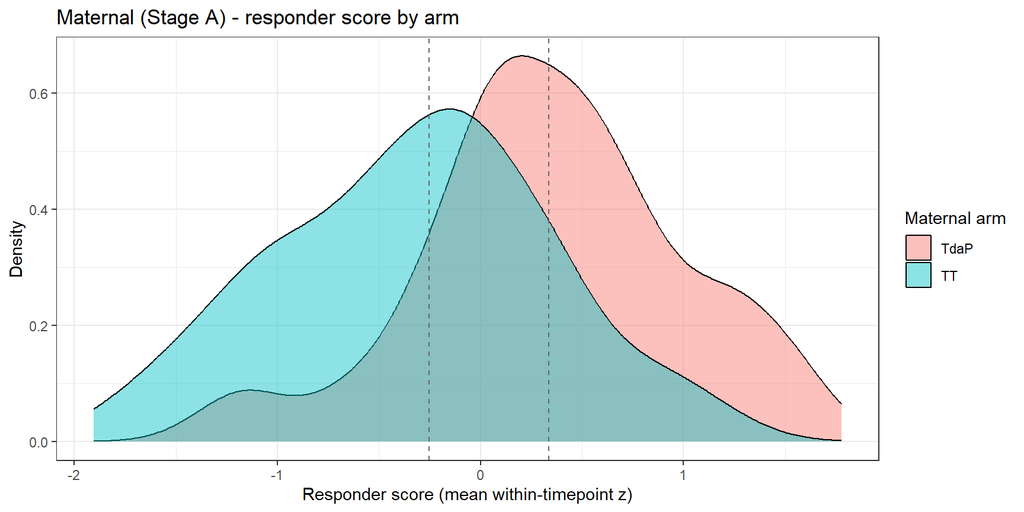

Median score by arm: TdaP = 0.361; TT = -0.311. Wilcoxon by arm: **W = 18691, p = 2.28e-16**.

- High responders (top tertile & breadth >= 60%): **66**; low responders: **67**.

PAM silhouette-selected **k = 2** (avg widths: 0.291, 0.214, 0.257).

Table A2. Maternal (Stage A) PAM subgroups (labelled by score rank).

| subgroup | n | median_z |
| --- | --- | --- |
| High responders | 154 | 0.440 |
| Low responders | 129 | -0.499 |

Table A3. Maternal (Stage A) score band x arm (counts).

|  | High score | Low score | Mid |
| --- | --- | --- | --- |
| TdaP | 77 | 21 | 53 |
| TT | 27 | 83 | 51 |

Fisher (simulated p): **p = 1e-04**.

## Stage B - Infant responder subgroups (InfMon2 baseline -> InfMon5/9 responses)

```r
cat(sprintf("Infant panel: binding **%s** + whole-bacterial **%s** at **%s** (%s is the transplacental baseline).\n\n",
            paste(RESP_FEATS, collapse = ", "),
            if (length(RESP_WHOLE)) paste(RESP_WHOLE, collapse = ", ") else "none",
            paste(INF_VIS, collapse = ", "), params$infant_baseline))
```

Infant panel: binding **PT_IgG, FHA_IgG, PRN_IgG** + whole-bacterial **WHOLE_SBA, WHOLE_WT_IgG** at **InfMon2, InfMon5, InfMon9** (InfMon2 is the transplacental baseline).

```r
print(knitr::kable(
  inf_long %>% dplyr::count(visit, feature, name = "n_subjects") %>%
    tidyr::pivot_wider(names_from = visit, values_from = n_subjects),
  caption = "Table B1. Infant responder-feature coverage (subjects) by feature and visit."))
```

Table B1. Infant responder-feature coverage (subjects) by feature and visit.

| feature | InfMon2 | InfMon5 | InfMon9 |
| --- | --- | --- | --- |
| FHA_IgG | 287 | 281 | 306 |
| PRN_IgG | 287 | 281 | 306 |
| PT_IgG | 287 | 281 | 306 |
| WHOLE_SBA | 238 | 239 | 234 |
| WHOLE_WT_IgG | 223 | 221 | 222 |

```r
inf_sg <- stage_report(inf_subject, inf_wide, "Infant (Stage B)", "B")
```

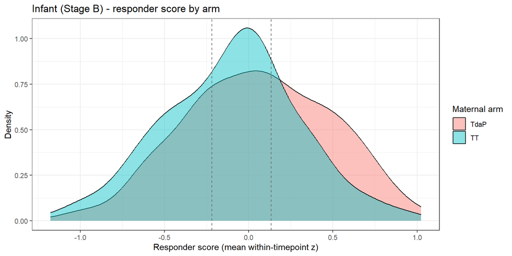

Median score by arm: TdaP = 0.061; TT = -0.072. Wilcoxon by arm: **W = 14593, p = 0.00152**.

- High responders (top tertile & breadth >= 60%): **32**; low responders: **44**.

PAM silhouette-selected **k = 2** (avg widths: 0.202, 0.121, 0.138).

Table B2. Infant (Stage B) PAM subgroups (labelled by score rank).

| subgroup | n | median_z |
| --- | --- | --- |
| High responders | 146 | 0.014 |
| Low responders | 118 | -0.028 |

Table B3. Infant (Stage B) score band x arm (counts).

|  | High score | Low score | Mid |
| --- | --- | --- | --- |
| TdaP | 64 | 45 | 42 |
| TT | 40 | 59 | 61 |

Fisher (simulated p): **p = 0.006**.

## Stage B2 - Single-assay responder subgroups

Beyond the multi-assay panel above, we additionally detect responder subgroups **on each assay alone** – PT_IgG, PRN_IgG, WHOLE_SBA, WHOLE_PTNA, WHOLE_WT_IgG – across the infant visits (InfMon2 -> InfMon5 -> InfMon9). Each single-assay panel is standardised within-timepoint (Blom z), scored as the subject mean z over that assay’s available visits, and clustered with the same PAM/silhouette engine (with `min_feat = 1` so a 1-3 column single-assay matrix is actually clustered rather than forced to the tertile fallback). This shows which individual assays carry a clean high/low responder split and how the maternal arm maps onto each. Note the panel spans InfMon2 (transplacental baseline) through the infant’s own responses, so a single-assay “responder” mixes supplied and self-made antibody exactly as the Stage-B panel does.

```r
single_feature_report <- function(sf) {
  if (!isTRUE(sf$ok)) {
    cat(sprintf("\n\n### %s\n\n*Skipped: %s.*\n\n", sf$feature, sf$reason))
    return(invisible(NULL))
  }
  cat(sprintf("\n\n### %s\n\n", sf$feature))
  subj <- sf$subject

  arm_test <- tryCatch(stats::wilcox.test(universal_z ~ arm_name, data = subj),
                       error = function(e) NULL)
  meds <- subj %>% dplyr::group_by(arm_name) %>%
    dplyr::summarize(median_z = round(median(universal_z, na.rm = TRUE), 3),
                     .groups = "drop")
  cat(sprintf("Single-assay score by maternal arm: %s.",
              paste(sprintf("%s = %.3f", meds$arm_name, meds$median_z),
                    collapse = "; ")))
  if (!is.null(arm_test))
    cat(sprintf(" Wilcoxon by arm: **W = %.0f, p = %.3g**.",
                unname(arm_test$statistic), arm_test$p.value))
  cat(sprintf("\n\nUniversal high: **%d**; universal low: **%d**.\n\n",
              sum(subj$universal_high, na.rm = TRUE),
              sum(subj$universal_low,  na.rm = TRUE)))

  sg <- sf$subgroups
  if (isTRUE(sg$ok)) {
    cat(sprintf("PAM silhouette-selected **k = %d** (avg widths: %s).\n\n",
                sg$best_k, paste(round(sg$sil, 3), collapse = ", ")))
    print(knitr::kable(
      sg$subgroup_tbl %>% dplyr::group_by(subgroup) %>%
        dplyr::summarize(n = dplyr::n(),
                         median_z = round(median(universal_z, na.rm = TRUE), 3),
                         .groups = "drop"),
      caption = sprintf("Single-assay PAM subgroups - %s (labelled by score rank).",
                        sf$feature)))
  } else {
    cat(sprintf("*PAM skipped (%s); tertile bands used.*\n\n", sg$reason))
    print(knitr::kable(subj %>% dplyr::count(score_band, name = "n"),
      caption = sprintf("Single-assay tertile bands - %s.", sf$feature)))
  }
  single_feature_dist_plot(sf)
  invisible(sf)
}

single_feature_results <- list()
for (f in params$single_feature_subgroups) {
  sf <- single_feature_subgroup(data_raw, INF_VIS, f, avail_feats, WHOLE_MAP,
                                breadth_thresh = params$breadth_thresh,
                                has_cluster = has_cluster)
  single_feature_results[[f]] <- sf
  single_feature_report(sf)
}
```

### PT_IgG

Single-assay score by maternal arm: TdaP = -0.026; TT = 0.073. Wilcoxon by arm: **W = 10934, p = 0.148**.

Universal high: **68**; universal low: **71**.

PAM silhouette-selected **k = 2** (avg widths: 0.381, 0.301, 0.297).

Single-assay PAM subgroups - PT_IgG (labelled by score rank).

| subgroup | n | median_z |
| --- | --- | --- |
| High responders | 110 | 0.312 |
| Low responders | 201 | -0.112 |

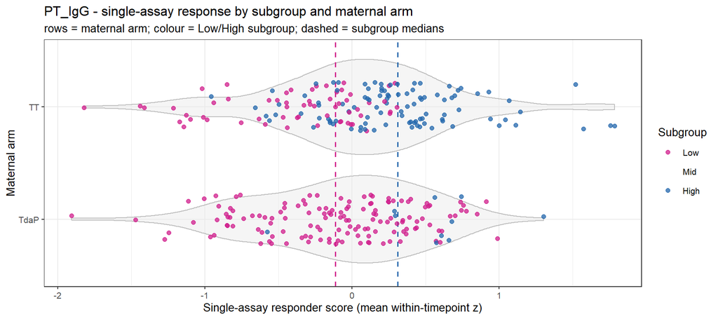

### PRN_IgG

Single-assay score by maternal arm: TdaP = 0.031; TT = -0.045. Wilcoxon by arm: **W = 14198, p = 0.00755**.

Universal high: **77**; universal low: **75**.

PAM silhouette-selected **k = 2** (avg widths: 0.323, 0.216, 0.271).

Single-assay PAM subgroups - PRN_IgG (labelled by score rank).

| subgroup | n | median_z |
| --- | --- | --- |
| High responders | 172 | 0.295 |
| Low responders | 139 | -0.433 |

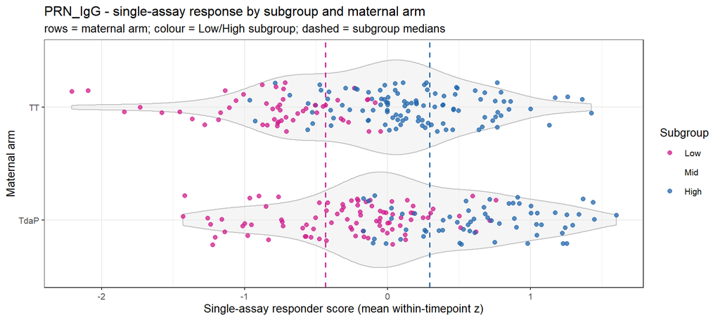

### WHOLE_SBA

Single-assay score by maternal arm: TdaP = 0.043; TT = -0.044. Wilcoxon by arm: **W = 7753, p = 0.249**.

Universal high: **60**; universal low: **72**.

PAM silhouette-selected **k = 2** (avg widths: 0.336, 0.322, 0.303).

Single-assay PAM subgroups - WHOLE_SBA (labelled by score rank).

| subgroup | n | median_z |
| --- | --- | --- |
| High responders | 97 | 0.426 |
| Low responders | 142 | -0.276 |

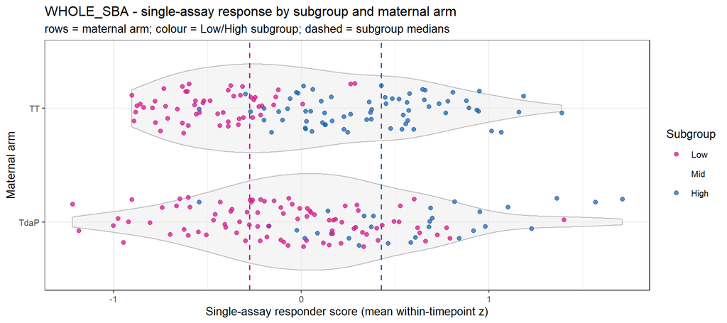

### WHOLE_PTNA

Single-assay score by maternal arm: TdaP = 0.082; TT = 0.082. Wilcoxon by arm: **W = 7202, p = 0.728**.

Universal high: **64**; universal low: **59**.

PAM silhouette-selected **k = 2** (avg widths: 0.331, 0.328, 0.288).

Single-assay PAM subgroups - WHOLE_PTNA (labelled by score rank).

| subgroup | n | median_z |
| --- | --- | --- |
| High responders | 70 | 0.541 |
| Low responders | 167 | -0.227 |

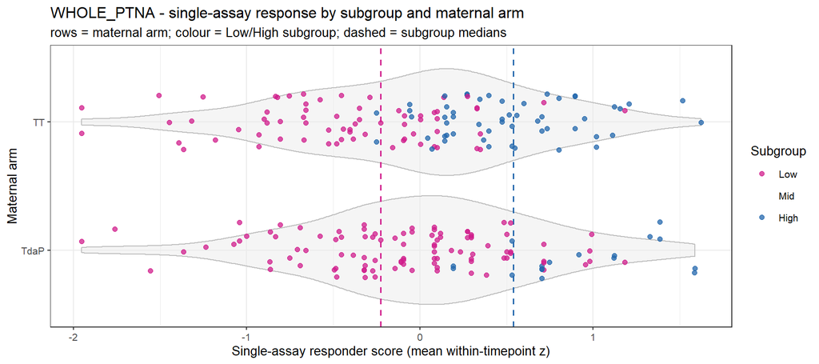

### WHOLE_WT_IgG

Single-assay score by maternal arm: TdaP = 0.039; TT = -0.169. Wilcoxon by arm: **W = 7484, p = 0.517**.

Universal high: **65**; universal low: **59**.

PAM silhouette-selected **k = 2** (avg widths: 0.356, 0.287, 0.305).

Single-assay PAM subgroups - WHOLE_WT_IgG (labelled by score rank).

| subgroup | n | median_z |
| --- | --- | --- |
| High responders | 76 | 0.921 |
| Low responders | 163 | -0.383 |

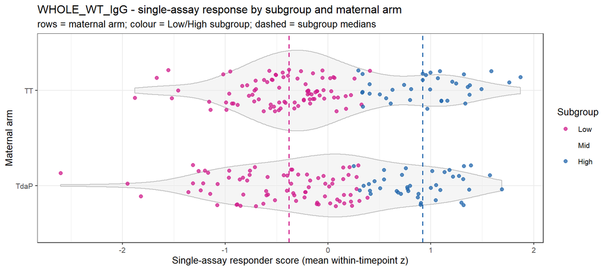

## Stage B3 - Cross-assay concordance of the single-assay subgroups

The single-assay subgroups above each split the cohort into Low/High independently. This section asks **how much those classifications agree across assays** – i.e. whether a subject called High on one antigen tends to be High on the others, or whether the Low/High axis is antigen-specific. We use each subject’s Low/High label from the five single-assay PAM subgroups (collapsed to High/Low), then report pairwise agreement (Cohen’s kappa and raw % agreement, on the subjects each pair classifies in common), the full agreement matrix, and how many assays each subject is classified High on. kappa near 1 = the assays sort subjects the same way; near 0 = independent; negative = systematic disagreement.

Table B3-1. Pairwise concordance of the single-assay High/Low classifications (Cohen’s kappa, % agreement, and n subjects classified by both assays).

| assay_x | assay_y | n | pct_agree | kappa |
| --- | --- | --- | --- | --- |
| PT_IgG | WHOLE_PTNA | 237 | 75.1 | 0.446 |
| PT_IgG | WHOLE_SBA | 239 | 66.9 | 0.307 |
| WHOLE_SBA | WHOLE_PTNA | 237 | 66.2 | 0.268 |
| PRN_IgG | WHOLE_SBA | 239 | 61.9 | 0.265 |
| PT_IgG | PRN_IgG | 311 | 61.4 | 0.252 |
| WHOLE_SBA | WHOLE_WT_IgG | 237 | 59.1 | 0.120 |
| PRN_IgG | WHOLE_PTNA | 237 | 50.6 | 0.084 |
| PRN_IgG | WHOLE_WT_IgG | 239 | 49.8 | 0.060 |
| WHOLE_PTNA | WHOLE_WT_IgG | 237 | 59.9 | 0.057 |
| PT_IgG | WHOLE_WT_IgG | 239 | 50.6 | -0.085 |

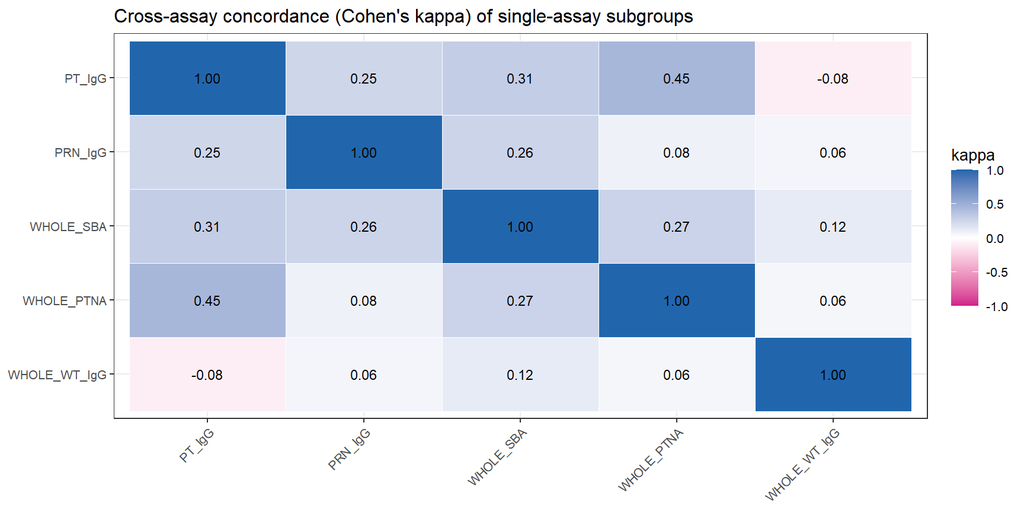

```r
sf_lab    <- single_feature_label_table(single_feature_results)
SF_ASSAYS <- intersect(params$single_feature_subgroups, names(sf_lab$wide))

if (length(SF_ASSAYS) >= 2 && nrow(sf_lab$long)) {
  ## (1) pairwise concordance ------------------------------------------------
  pc <- pairwise_concordance(sf_lab$wide, SF_ASSAYS)
  print(knitr::kable(
    pc %>% dplyr::mutate(pct_agree = round(100 * pct_agree, 1),
                         kappa     = round(kappa, 3)) %>%
      dplyr::arrange(dplyr::desc(kappa)),
    caption = paste0("Table B3-1. Pairwise concordance of the single-assay ",
                     "High/Low classifications (Cohen's kappa, % agreement, ",
                     "and n subjects classified by both assays).")))

  ## kappa heatmap
  km  <- kappa_matrix(pc, SF_ASSAYS)
  kdf <- expand.grid(x = SF_ASSAYS, y = SF_ASSAYS,
                     KEEP.OUT.ATTRS = FALSE, stringsAsFactors = FALSE)
  kdf$kappa <- mapply(function(a, b) km[a, b], kdf$x, kdf$y)
  kdf$x <- factor(kdf$x, levels = SF_ASSAYS)
  kdf$y <- factor(kdf$y, levels = rev(SF_ASSAYS))
  print(ggplot(kdf, aes(x, y, fill = kappa)) +
    geom_tile(color = "white") +
    geom_text(aes(label = ifelse(is.na(kappa), "", sprintf("%.2f", kappa))),
              size = 3) +
    scale_fill_gradient2(low = "#d01c8b", mid = "white", high = "#2166ac",
                         midpoint = 0, limits = c(-1, 1), na.value = "grey90",
                         name = "kappa") +
    labs(title = "Cross-assay concordance (Cohen's kappa) of single-assay subgroups",
         x = NULL, y = NULL) +
    theme_bw(base_size = 10) +
    theme(axis.text.x = element_text(angle = 45, hjust = 1)))
  cat("\n\n")

  ## (2) per-subject 'High count' across assays ------------------------------
  hi <- sf_lab$long %>%
    dplyr::group_by(subject_accession) %>%
    dplyr::summarize(n_assays = dplyr::n(),
                     n_high = sum(level == "High"),
                     n_low  = sum(level == "Low"), .groups = "drop")

  full <- hi %>% dplyr::filter(n_assays == length(SF_ASSAYS))
  cat(sprintf(paste0("\n\nAmong the **%d** subjects classified on all %d single-assay ",
                     "panels: **%d** are High on every assay, **%d** are Low on every ",
                     "assay, and **%d** are mixed -- the size of the mixed group is the ",
                     "direct measure of antigen-specific (discordant) responder status.\n\n"),
              nrow(full), length(SF_ASSAYS),
              sum(full$n_high == length(SF_ASSAYS)),
              sum(full$n_low  == length(SF_ASSAYS)),
              sum(full$n_high > 0 & full$n_high < length(SF_ASSAYS))))

  if (nrow(full)) {
    print(ggplot(full, aes(factor(n_high))) +
      geom_bar(fill = "#2166ac") +
      labs(title = sprintf("High-assay count among subjects classified on all %d single-assay panels",
                           length(SF_ASSAYS)),
           x = "Number of assays on which the subject is classified High",
           y = "Subjects") +
      theme_bw(base_size = 10))
    print(knitr::kable(
      full %>% dplyr::count(n_high, name = "n_subjects") %>% dplyr::arrange(n_high),
      caption = "Table B3-2. Distribution of the High-assay count (subjects classified on all single-assay panels)."))
  }
} else {
  cat("*Fewer than two single-assay subgroupings available - no concordance analysis.*\n\n")
  sf_lab <- list(long = dplyr::tibble(), wide = dplyr::tibble())
  hi <- dplyr::tibble(subject_accession = character(),
                      n_assays = integer(), n_high = integer(), n_low = integer())
}
```

Among the **237** subjects classified on all 5 single-assay panels: **10** are High on every assay, **40** are Low on every assay, and **187** are mixed – the size of the mixed group is the direct measure of antigen-specific (discordant) responder status.

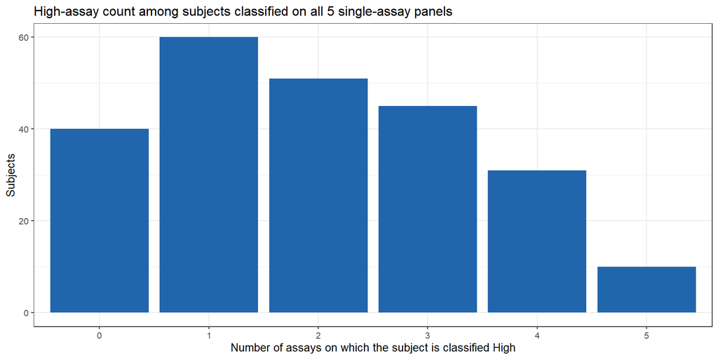

Table B3-2. Distribution of the High-assay count (subjects classified on all single-assay panels).

| n_high | n_subjects |
| --- | --- |
| 0 | 40 |
| 1 | 60 |
| 2 | 51 |
| 3 | 45 |
| 4 | 31 |
| 5 | 10 |

## Stage C - Linkage: does the maternal response carry forward?

```r
mat_g <- group_of(mat_subject, mat_sg) %>%
  dplyr::select(subject_accession, maternal_group = group, maternal_z = universal_z)
inf_g <- group_of(inf_subject, inf_sg) %>%
  dplyr::select(subject_accession, infant_group = group, infant_z = universal_z)
link <- dplyr::inner_join(mat_g, inf_g, by = "subject_accession")

## Collapse the detailed subgroup labels to {High, Low, Mid} and form the
## maternal_infant linkage class used by the Stage-D low/low profiling.
link$maternal_level <- collapse_resp_level(link$maternal_group)
link$infant_level   <- collapse_resp_level(link$infant_group)
link$link_class     <- paste(link$maternal_level, link$infant_level, sep = "_")

## (1) maternal score vs infant (pooled) score
cor_mi <- tryCatch(
  stats::cor.test(link$maternal_z, link$infant_z, method = params$cor_method,
                  exact = FALSE), error = function(e) NULL)
cat("### Maternal score vs infant score\n\n")
```

### Maternal score vs infant score

```r
if (!is.null(cor_mi))
  cat(sprintf("Across **%d** linked mother-infant pairs, the maternal responder score and the pooled infant score correlate at **%.2f** (%s, p = %.3g).\n\n",
              nrow(link), unname(cor_mi$estimate), params$cor_method, cor_mi$p.value))
```

Across **311** linked mother-infant pairs, the maternal responder score and the pooled infant score correlate at **0.17** (spearman, p = 0.0025).

```r
## (2) maternal subgroup x infant subgroup
cat("### Maternal subgroup x infant subgroup\n\n")
```

### Maternal subgroup x infant subgroup

```r
tab_mi <- table(link$maternal_group, link$infant_group)
ft_mi  <- tryCatch(stats::fisher.test(tab_mi, simulate.p.value = TRUE, B = 1e4),
                   error = function(e) NULL)
print(knitr::kable(as.data.frame.matrix(tab_mi),
      caption = "Table C1. Maternal subgroup (rows) x infant subgroup (cols), linked pairs."))
```

Table C1. Maternal subgroup (rows) x infant subgroup (cols), linked pairs.

|  | High responders | High score | Low responders | Low score | Mid |
| --- | --- | --- | --- | --- | --- |
| High responders | 36 | 9 | 87 | 17 | 4 |
| High score | 3 | 0 | 8 | 0 | 0 |
| Low responders | 98 | 3 | 14 | 11 | 3 |
| Low score | 4 | 0 | 4 | 0 | 0 |
| Mid | 5 | 0 | 5 | 0 | 0 |

```r
if (!is.null(ft_mi)) cat(sprintf("\nFisher (simulated p): **p = %.3g**.\n\n", ft_mi$p.value))
```

Fisher (simulated p): **p = 1e-04**.

```r
## (3) infant trajectory across visits, stratified by MATERNAL subgroup:
##     baseline (InfMon2) -> responses (InfMon5, InfMon9)
cat("### Infant trajectory by maternal subgroup (baseline -> responses)\n\n")
```

### Infant trajectory by maternal subgroup (baseline -> responses)

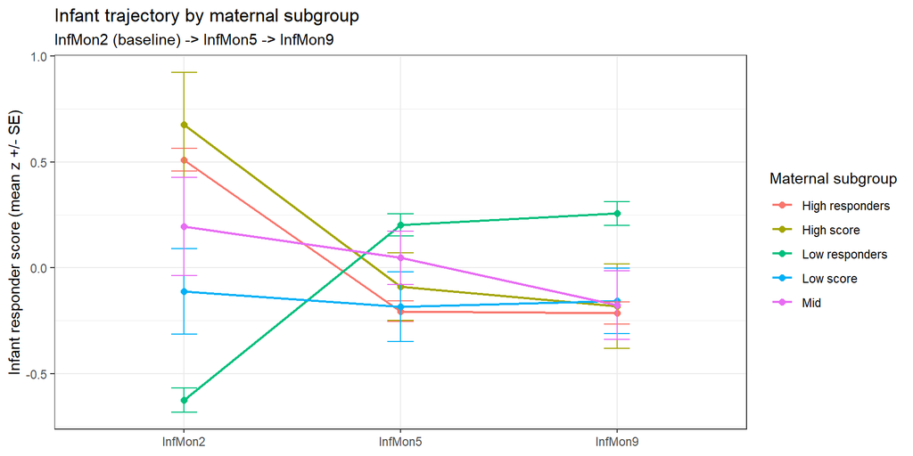

Table C2. Infant score by maternal subgroup and infant visit (mean z, SE, n).

| maternal_group | visit | mean_z | se | n |
| --- | --- | --- | --- | --- |
| High responders | InfMon2 | 0.510 | 0.053 | 136 |
| High responders | InfMon5 | -0.206 | 0.049 | 134 |
| High responders | InfMon9 | -0.214 | 0.053 | 151 |
| High score | InfMon2 | 0.675 | 0.249 | 11 |
| High score | InfMon5 | -0.089 | 0.160 | 11 |
| High score | InfMon9 | -0.181 | 0.200 | 11 |
| Low responders | InfMon2 | -0.624 | 0.057 | 122 |
| Low responders | InfMon5 | 0.203 | 0.052 | 118 |
| Low responders | InfMon9 | 0.256 | 0.056 | 127 |
| Low score | InfMon2 | -0.111 | 0.202 | 8 |
| Low score | InfMon5 | -0.184 | 0.164 | 8 |
| Low score | InfMon9 | -0.157 | 0.155 | 7 |
| Mid | InfMon2 | 0.194 | 0.231 | 10 |
| Mid | InfMon5 | 0.046 | 0.126 | 10 |
| Mid | InfMon9 | -0.177 | 0.162 | 10 |

```r
traj <- inf_by_visit %>%
  dplyr::left_join(dplyr::select(mat_g, subject_accession, maternal_group),
                   by = "subject_accession") %>%
  dplyr::filter(!is.na(maternal_group), visit %in% INF_VIS) %>%
  dplyr::mutate(visit = factor(visit, levels = INF_VIS)) %>%
  dplyr::group_by(maternal_group, visit) %>%
  dplyr::summarize(mean_z = mean(score_visit, na.rm = TRUE),
                   se = stats::sd(score_visit, na.rm = TRUE) /
                        sqrt(sum(is.finite(score_visit))),
                   n = dplyr::n(), .groups = "drop")

if (nrow(traj)) {
  print(ggplot(traj, aes(visit, mean_z, color = maternal_group, group = maternal_group)) +
    geom_line(linewidth = 0.8) + geom_point(size = 2) +
    geom_errorbar(aes(ymin = mean_z - se, ymax = mean_z + se), width = 0.12) +
    labs(x = NULL, y = "Infant responder score (mean z +/- SE)",
         color = "Maternal subgroup",
         title = "Infant trajectory by maternal subgroup",
         subtitle = sprintf("%s (baseline) -> %s",
                            params$infant_baseline,
                            paste(setdiff(INF_VIS, params$infant_baseline), collapse = " -> "))) +
    theme_bw(base_size = 11))
  print(knitr::kable(
    traj %>% dplyr::mutate(mean_z = round(mean_z, 3), se = round(se, 3)),
    caption = "Table C2. Infant score by maternal subgroup and infant visit (mean z, SE, n)."))
}
```

## Stage D - Profiling the low/low subjects

The Stage-C verdict flags the **low-into-low** pairs – subjects who are *low* maternal responders **and** *low* infant responders – as the consistent non-responders. Here we identify those individuals, profile their serology across the full standardised panel (maternal binding at PregEarly/MatBirth plus the infant binding/functional assays at InfMon2/5/9), and contrast that profile with the other linkage classes to ask **what is different about them**.

```r
## Combined standardised profile panel (maternal + infant feature@visit z).
prof_long <- dplyr::bind_rows(
  dplyr::mutate(mat_long, panel = "maternal"),
  dplyr::mutate(inf_long, panel = "infant"))

## Per-subject class + arms.
cls <- link %>%
  dplyr::select(subject_accession, link_class, maternal_level, infant_level)
cls$maternal_arm <- mat_subject$arm_name[
  match(cls$subject_accession, mat_subject$subject_accession)]
cls <- attach_infant_arm(cls, infant_arm_tbl)

## (D1) collapsed class grid + low/low count -------------------------------
cat("### Collapsed maternal x infant linkage classes\n\n")
```

### Collapsed maternal x infant linkage classes

```r
tab_lvl <- table(link$maternal_level, link$infant_level)
print(knitr::kable(as.data.frame.matrix(tab_lvl),
      caption = "Table D1. Collapsed maternal (rows) x infant (cols) responder levels."))
```

Table D1. Collapsed maternal (rows) x infant (cols) responder levels.

|  | High | Low | Mid |
| --- | --- | --- | --- |
| High | 48 | 112 | 4 |
| Low | 105 | 29 | 3 |
| Mid | 5 | 5 | 0 |

```r
n_ll <- sum(link$link_class == "Low_Low", na.rm = TRUE)
cat(sprintf("\n\n**Low/low subjects (maternal Low AND infant Low): n = %d.**\n\n", n_ll))
```

**Low/low subjects (maternal Low AND infant Low): n = 29.**

```r
## (D2) the low/low roster -------------------------------------------------
roster <- cls %>%
  dplyr::filter(link_class == "Low_Low") %>%
  dplyr::left_join(dplyr::select(link, subject_accession, maternal_z, infant_z),
                   by = "subject_accession") %>%
  dplyr::transmute(subject_accession, maternal_arm, infant_arm,
                   maternal_z = round(maternal_z, 2),
                   infant_z   = round(infant_z, 2)) %>%
  dplyr::arrange(infant_z)
if (nrow(roster))
  print(knitr::kable(roster,
        caption = "Table D2. The low/low subjects: arms and responder scores."))
```

Table D2. The low/low subjects: arms and responder scores.

| subject_accession | maternal_arm | infant_arm | maternal_z | infant_z |
| --- | --- | --- | --- | --- |
| 103 | TT | aP | -1.72 | -1.18 |
| 150 | TT | wP | -0.61 | -1.01 |
| 28 | TdaP | wP | -0.19 | -0.91 |
| 99 | TT | wP | -0.34 | -0.73 |
| 110 | TT | aP | -0.99 | -0.73 |
| 113 | TT | aP | -1.91 | -0.57 |
| 126 | TT | aP | -1.13 | -0.51 |
| 231 | TdaP | aP | -0.31 | -0.50 |
| 114 | TT | aP | -0.66 | -0.49 |
| 118 | TT | wP | -0.45 | -0.40 |
| 144 | TT | wP | -0.09 | -0.38 |
| 634 | TdaP | wP | -0.35 | -0.37 |
| 143 | TT | wP | -0.18 | -0.36 |
| 25 | TdaP | wP | -0.12 | -0.31 |
| 124 | TT | aP | -0.17 | -0.27 |
| 98 | TT | aP | -0.66 | -0.25 |
| 606 | TdaP | aP | -1.22 | -0.20 |
| 161 | TdaP | aP | -1.25 | -0.19 |
| 178 | TdaP | wP | -0.23 | -0.11 |
| 644 | TT | wP | -0.06 | -0.11 |
| 608 | TdaP | wP | -1.17 | -0.06 |
| 79 | TdaP | wP | -0.25 | 0.08 |
| 633 | TdaP | wP | -0.30 | 0.12 |
| 171 | TdaP | wP | -0.66 | 0.13 |
| 689 | TdaP | wP | -0.46 | 0.15 |
| 47 | TT | wP | -0.49 | 0.41 |
| 61 | TdaP | aP | -0.37 | 0.41 |
| 40 | TdaP | aP | -0.50 | 0.42 |
| 93 | TdaP | aP | -0.47 | 0.48 |

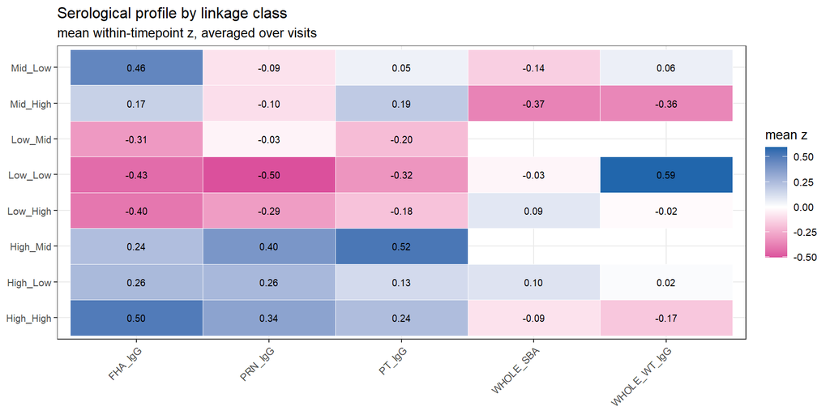

Table D3. Mean within-timepoint z by linkage class and assay (averaged over visits).

| link_class | FHA_IgG | PRN_IgG | PT_IgG | WHOLE_SBA | WHOLE_WT_IgG |
| --- | --- | --- | --- | --- | --- |
| High_High | 0.503 | 0.345 | 0.243 | -0.087 | -0.168 |
| High_Low | 0.256 | 0.262 | 0.133 | 0.101 | 0.016 |
| High_Mid | 0.238 | 0.396 | 0.521 | NA | NA |
| Low_High | -0.404 | -0.293 | -0.184 | 0.088 | -0.015 |
| Low_Low | -0.432 | -0.503 | -0.319 | -0.031 | 0.595 |
| Low_Mid | -0.306 | -0.035 | -0.201 | NA | NA |
| Mid_High | 0.169 | -0.100 | 0.193 | -0.369 | -0.360 |
| Mid_Low | 0.461 | -0.086 | 0.051 | -0.144 | 0.056 |

```r
## (D3) serological profile by class (assay-level, averaged over visits) ----
prof_long$assay <- sub("@.*$", "", prof_long$key)
cls_min   <- dplyr::distinct(dplyr::select(cls, subject_accession, link_class))
prof_assay <- prof_long %>%
  dplyr::left_join(cls_min, by = "subject_accession") %>%
  dplyr::filter(!is.na(link_class)) %>%
  dplyr::group_by(link_class, assay) %>%
  dplyr::summarize(mean_z = mean(z, na.rm = TRUE),
                   n = sum(is.finite(z)), .groups = "drop")

if (nrow(prof_assay)) {
  print(ggplot(prof_assay, aes(assay, link_class, fill = mean_z)) +
    geom_tile(color = "white") +
    geom_text(aes(label = sprintf("%.2f", mean_z)), size = 2.6) +
    scale_fill_gradient2(low = "#d01c8b", mid = "white", high = "#2166ac",
                         midpoint = 0, name = "mean z") +
    labs(title = "Serological profile by linkage class",
         subtitle = "mean within-timepoint z, averaged over visits",
         x = NULL, y = NULL) +
    theme_bw(base_size = 10) +
    theme(axis.text.x = element_text(angle = 45, hjust = 1)))
  print(knitr::kable(
    prof_assay %>% dplyr::select(link_class, assay, mean_z) %>%
      dplyr::mutate(mean_z = round(mean_z, 3)) %>%
      tidyr::pivot_wider(names_from = assay, values_from = mean_z,
                         id_cols = link_class),
    caption = "Table D3. Mean within-timepoint z by linkage class and assay (averaged over visits)."))
}
```

```r
## (D4) which feature@visit keys most distinguish the low/low subjects ------
dx <- distinguishing_features(prof_long, link, focal = "Low_Low")
if (nrow(dx)) {
  print(knitr::kable(
    utils::head(dx, 12) %>%
      dplyr::transmute(key, n_focal, n_other,
                       mean_focal = round(mean_focal, 2),
                       mean_other = round(mean_other, 2),
                       diff = round(diff, 2),
                       p = signif(p, 3), p_BH = signif(p_BH, 3)),
    caption = paste0("Table D4. feature@visit keys where low/low subjects ",
                     "deviate most from the rest (most negative diff first); ",
                     "Wilcoxon low/low vs rest, BH-adjusted.")))
  top_neg <- utils::head(dx$key[order(dx$diff)], 5)
  cat(sprintf("\n\nThe low/low subjects sit furthest below the rest of the cohort on: **%s**.\n\n",
              paste(top_neg, collapse = ", ")))
}
```

Table D4. feature@visit keys where low/low subjects deviate most from the rest (most negative diff first); Wilcoxon low/low vs rest, BH-adjusted.

|  | key | n_focal | n_other | mean_focal | mean_other | diff | p | p_BH |
| --- | --- | --- | --- | --- | --- | --- | --- | --- |
| 1 | FHA_IgG@PregEarly | 29 | 282 | -0.78 | 0.08 | -0.86 | 1.68e-05 | 0.000353 |
| 13 | PRN_IgG@InfMon5 | 21 | 260 | -0.71 | 0.06 | -0.77 | 4.02e-04 | 0.002750 |
| 2 | PRN_IgG@PregEarly | 29 | 282 | -0.66 | 0.07 | -0.73 | 6.60e-05 | 0.000693 |
| 5 | PRN_IgG@MatBirth | 25 | 257 | -0.63 | 0.07 | -0.70 | 5.24e-04 | 0.002750 |
| 14 | PT_IgG@InfMon5 | 21 | 260 | -0.60 | 0.05 | -0.64 | 3.74e-03 | 0.015700 |
| 4 | FHA_IgG@MatBirth | 25 | 257 | -0.51 | 0.05 | -0.56 | 1.41e-02 | 0.042200 |
| 3 | PT_IgG@PregEarly | 29 | 282 | -0.45 | 0.04 | -0.49 | 4.64e-03 | 0.016200 |
| 19 | PT_IgG@InfMon9 | 28 | 278 | -0.41 | 0.04 | -0.45 | 3.24e-02 | 0.061900 |
| 12 | FHA_IgG@InfMon5 | 21 | 260 | -0.40 | 0.03 | -0.43 | 3.77e-02 | 0.065900 |
| 17 | FHA_IgG@InfMon9 | 28 | 278 | -0.36 | 0.04 | -0.40 | 5.64e-02 | 0.091100 |
| 18 | PRN_IgG@InfMon9 | 28 | 278 | -0.34 | 0.03 | -0.38 | 8.38e-02 | 0.117000 |
| 6 | PT_IgG@MatBirth | 25 | 257 | -0.31 | 0.03 | -0.34 | 7.54e-02 | 0.113000 |

The low/low subjects sit furthest below the rest of the cohort on: **FHA_IgG@PregEarly, PRN_IgG@InfMon5, PRN_IgG@PregEarly, PRN_IgG@MatBirth, PT_IgG@InfMon5**.

```r
## (D5) arm composition of the low/low subjects ----------------------------
cls$is_ll <- ifelse(cls$link_class == "Low_Low", "Low/low", "Other")
cat("### Arm composition of the low/low subjects\n\n")
```

### Arm composition of the low/low subjects

```r
print(knitr::kable(as.data.frame.matrix(table(cls$is_ll, cls$maternal_arm)),
      caption = "Table D5. Maternal arm (TdaP / TT) by low/low vs other."))
```

Table D5. Maternal arm (TdaP / TT) by low/low vs other.

|  | TdaP | TT |
| --- | --- | --- |
| Low/low | 15 | 14 |
| Other | 136 | 146 |

```r
ft_arm <- tryCatch(stats::fisher.test(table(cls$is_ll, cls$maternal_arm)),
                   error = function(e) NULL)
if (!is.null(ft_arm))
  cat(sprintf("\nFisher (maternal arm x low/low): **p = %.3g**.\n\n", ft_arm$p.value))
```

Fisher (maternal arm x low/low): **p = 0.846**.

```r
if (!is.null(infant_arm_tbl) && any(!is.na(cls$infant_arm))) {
  print(knitr::kable(as.data.frame.matrix(table(cls$is_ll, cls$infant_arm)),
        caption = "Table D6. Infant arm (wP / aP) by low/low vs other."))
  ft_inf <- tryCatch(stats::fisher.test(table(cls$is_ll, cls$infant_arm)),
                     error = function(e) NULL)
  if (!is.null(ft_inf))
    cat(sprintf("\nFisher (infant arm x low/low): **p = %.3g**.\n\n", ft_inf$p.value))
}
```

Table D6. Infant arm (wP / aP) by low/low vs other.

|  | wP | aP |
| --- | --- | --- |
| Low/low | 16 | 13 |
| Other | 140 | 142 |

Fisher (infant arm x low/low): **p = 0.697**.

### Low/low decomposed across the single-assay subgroups

The combined maternal and infant scores compress many assays into one number, which makes a “low/low” label hard to read mechanistically. Here we map each low/low subject onto the Stage-B3 single-assay classifications, so the combined label is decomposed into **which individual assay signals are Low or High** for these subjects – showing the relative contribution of each antigen/analyte.

```r
ll_ids <- link$subject_accession[which(link$link_class == "Low_Low")]
cat(sprintf("Low/low subjects: **n = %d**.\n\n", length(ll_ids)))
```

Low/low subjects: **n = 29**.

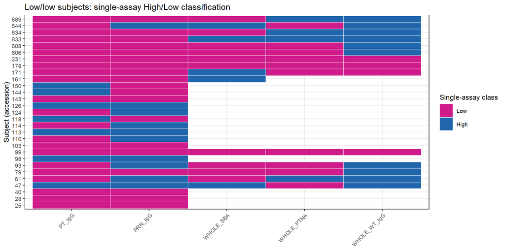

Table D7. For each single-assay subgroup: the % of low/low subjects (n_ll classified on that assay) called Low, the cohort baseline % Low, and the enrichment (difference). Higher % Low = that assay signal contributes more to the low/low phenotype.

| assay | n_ll | ll_pct_low | cohort_pct_low | enrichment |
| --- | --- | --- | --- | --- |
| PT_IgG | 29 | 75.9 | 64.6 | 11.3 |
| WHOLE_PTNA | 14 | 71.4 | 70.5 | 0.9 |
| WHOLE_SBA | 15 | 66.7 | 59.4 | 7.3 |
| PRN_IgG | 29 | 65.5 | 44.7 | 20.8 |
| WHOLE_WT_IgG | 14 | 28.6 | 68.2 | -39.6 |

```r
if (length(ll_ids) && nrow(sf_lab$long)) {
  ll_lab <- sf_lab$long %>% dplyr::filter(subject_accession %in% ll_ids)

  if (nrow(ll_lab)) {
    ll_lab$assay <- factor(ll_lab$assay, levels = SF_ASSAYS)
    ll_lab$level <- factor(ll_lab$level, levels = c("Low", "High"))

    ## (1) per-subject x assay map of Low/High for the low/low subjects
    print(ggplot(ll_lab,
                 aes(assay, factor(subject_accession), fill = level)) +
      geom_tile(color = "white") +
      scale_fill_manual(values = c(Low = "#d01c8b", High = "#2166ac"),
                        drop = FALSE, name = "Single-assay class") +
      labs(title = "Low/low subjects: single-assay High/Low classification",
           x = NULL, y = "Subject (accession)") +
      theme_bw(base_size = 9) +
      theme(axis.text.x = element_text(angle = 45, hjust = 1)))
    cat("\n\n")

    ## (2) per-assay: % of low/low classified Low vs the cohort baseline
    base_rate <- sf_lab$long %>% dplyr::group_by(assay) %>%
      dplyr::summarize(cohort_pct_low = 100 * mean(level == "Low"),
                       .groups = "drop")
    ll_rate <- ll_lab %>% dplyr::group_by(assay) %>%
      dplyr::summarize(n_ll = dplyr::n(),
                       ll_pct_low = 100 * mean(level == "Low"), .groups = "drop")
    cmp <- ll_rate %>%
      dplyr::left_join(base_rate, by = "assay") %>%
      dplyr::mutate(ll_pct_low     = round(ll_pct_low, 1),
                    cohort_pct_low = round(cohort_pct_low, 1),
                    enrichment     = round(ll_pct_low - cohort_pct_low, 1)) %>%
      dplyr::arrange(dplyr::desc(ll_pct_low))
    print(knitr::kable(cmp,
      caption = paste0("Table D7. For each single-assay subgroup: the % of low/low ",
                       "subjects (n_ll classified on that assay) called Low, the ",
                       "cohort baseline % Low, and the enrichment (difference). ",
                       "Higher % Low = that assay signal contributes more to the ",
                       "low/low phenotype.")))

    ## (3) how concordant is the low/low low-ness across assays?
    ll_hi <- hi %>% dplyr::filter(subject_accession %in% ll_ids)
    if (nrow(ll_hi)) {
      cat(sprintf(paste0("\n\nAcross the single-assay panels, low/low subjects are ",
                         "classified **Low** on a median of **%g** of the assays they ",
                         "were scored on (range %d-%d); **%d of %d** are Low on *every* ",
                         "assay they were classified on, versus High on at least one for ",
                         "the remaining %d.\n\n"),
                  stats::median(ll_hi$n_low, na.rm = TRUE),
                  min(ll_hi$n_low), max(ll_hi$n_low),
                  sum(ll_hi$n_low == ll_hi$n_assays), nrow(ll_hi),
                  sum(ll_hi$n_low <  ll_hi$n_assays)))
      cat(sprintf(paste0("The assay signals contributing most consistently to the ",
                         "low/low phenotype (highest %% Low) are, in order: **%s**. ",
                         "Assays where low/low subjects are *not* uniformly Low identify ",
                         "where the combined label is driven by other antigens rather ",
                         "than a global deficit.\n\n"),
                  paste(as.character(cmp$assay), collapse = ", ")))
    }
  } else {
    cat("*No low/low subjects were classified by any single-assay subgroup.*\n\n")
  }
} else {
  cat("*No low/low subjects or no single-assay labels available to map.*\n\n")
}
```

Across the single-assay panels, low/low subjects are classified **Low** on a median of **2** of the assays they were scored on (range 0-5); **8 of 29** are Low on *every* assay they were classified on, versus High on at least one for the remaining 21.

The assay signals contributing most consistently to the low/low phenotype (highest % Low) are, in order: **PT_IgG, WHOLE_PTNA, WHOLE_SBA, PRN_IgG, WHOLE_WT_IgG**. Assays where low/low subjects are *not* uniformly Low identify where the combined label is driven by other antigens rather than a global deficit.

# Q6 (extended) - Pan-assay responder classes and the low/low contrast

## Stage E - Always-high / always-low / mixed classes from the concordance

The Stage-B3 high-assay count partitions the subjects who were classified on **all** single-assay panels into three pan-assay classes: **always-high** (High on every assay), **always-low** (Low on every assay), and the **mixed middle** (High on some, Low on others). Here we give each class a serological profile across the full standardised panel and trace the infant trajectory, then (next subsection) contrast the concordance-defined always-low group with the linkage-defined low/low group, since the two are different constructions of “low”.

```r
n_sf <- length(SF_ASSAYS)
conc <- hi %>%
  dplyr::filter(n_assays == n_sf) %>%
  dplyr::mutate(conc_class = dplyr::case_when(
    n_high == n_sf ~ "Always-high",
    n_low  == n_sf ~ "Always-low",
    TRUE           ~ "Mixed-middle"))
CC_LEVELS <- c("Always-low", "Mixed-middle", "Always-high")
conc$conc_class <- factor(conc$conc_class, levels = CC_LEVELS)

cat(sprintf(paste0("Defined on the **%d** subjects classified on all %d single-assay ",
                   "panels: **%d** always-high, **%d** mixed-middle, **%d** always-low.\n\n"),
            nrow(conc), n_sf,
            sum(conc$conc_class == "Always-high"),
            sum(conc$conc_class == "Mixed-middle"),
            sum(conc$conc_class == "Always-low")))
```

Defined on the **237** subjects classified on all 5 single-assay panels: **10** always-high, **187** mixed-middle, **40** always-low.

```r
print(knitr::kable(conc %>% dplyr::count(conc_class, name = "n_subjects"),
      caption = "Table E1. Pan-assay concordance classes (subjects classified on all single-assay panels)."))
```

Table E1. Pan-assay concordance classes (subjects classified on all single-assay panels).

| conc_class | n_subjects |
| --- | --- |
| Always-low | 40 |
| Mixed-middle | 187 |
| Always-high | 10 |

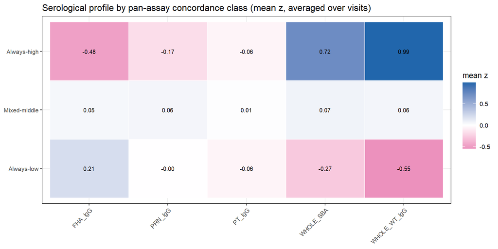

```r
## (E2) serological profile across the full panel (assay-level, over visits)
prof_conc <- assay_profile_table(prof_long, conc, "conc_class")
print(profile_heatmap(prof_conc,
      "Serological profile by pan-assay concordance class (mean z, averaged over visits)",
      grp_levels = CC_LEVELS))
```

```r
print(knitr::kable(
  prof_conc %>% dplyr::mutate(mean_z = round(mean_z, 3)) %>%
    dplyr::select(grp, assay, mean_z) %>%
    tidyr::pivot_wider(names_from = assay, values_from = mean_z, id_cols = grp),
  caption = "Table E2. Mean within-timepoint z by concordance class and assay (averaged over visits)."))
```

Table E2. Mean within-timepoint z by concordance class and assay (averaged over visits).

| grp | FHA_IgG | PRN_IgG | PT_IgG | WHOLE_SBA | WHOLE_WT_IgG |
| --- | --- | --- | --- | --- | --- |
| Always-low | 0.205 | -0.003 | -0.057 | -0.272 | -0.550 |
| Mixed-middle | 0.048 | 0.057 | 0.009 | 0.074 | 0.062 |
| Always-high | -0.477 | -0.171 | -0.056 | 0.725 | 0.995 |

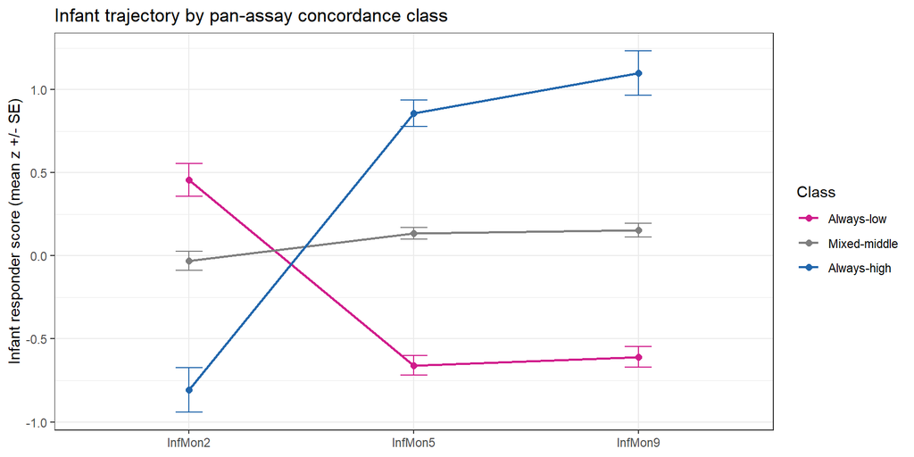

```r
## (E3) infant responder trajectory by class
traj_cc <- inf_by_visit %>%
  dplyr::left_join(dplyr::select(conc, subject_accession, conc_class),
                   by = "subject_accession") %>%
  dplyr::filter(!is.na(conc_class), visit %in% INF_VIS) %>%
  dplyr::mutate(visit = factor(visit, levels = INF_VIS)) %>%
  dplyr::group_by(conc_class, visit) %>%
  dplyr::summarize(mean_z = mean(score_visit, na.rm = TRUE),
                   se = stats::sd(score_visit, na.rm = TRUE) /
                        sqrt(sum(is.finite(score_visit))),
                   n = dplyr::n(), .groups = "drop")
if (nrow(traj_cc))
  print(ggplot(traj_cc, aes(visit, mean_z, color = conc_class, group = conc_class)) +
    geom_line(linewidth = 0.8) + geom_point(size = 2) +
    geom_errorbar(aes(ymin = mean_z - se, ymax = mean_z + se), width = 0.12) +
    scale_color_manual(values = c("Always-low" = "#d01c8b",
                                  "Mixed-middle" = "grey50",
                                  "Always-high" = "#2166ac"), name = "Class") +
    labs(x = NULL, y = "Infant responder score (mean z +/- SE)",
         title = "Infant trajectory by pan-assay concordance class") +
    theme_bw(base_size = 11))
```

```r
## (E4) arm composition
conc2 <- conc %>% dplyr::left_join(
  dplyr::select(cls, subject_accession, maternal_arm, infant_arm),
  by = "subject_accession")
print(knitr::kable(as.data.frame.matrix(table(conc2$conc_class, conc2$maternal_arm)),
      caption = "Table E3. Maternal arm (TT / TdaP) by concordance class."))
```

Table E3. Maternal arm (TT / TdaP) by concordance class.

|  | TdaP | TT |
| --- | --- | --- |
| Always-low | 31 | 9 |
| Mixed-middle | 85 | 102 |
| Always-high | 0 | 10 |

```r
if (!is.null(infant_arm_tbl) && any(!is.na(conc2$infant_arm)))
  print(knitr::kable(as.data.frame.matrix(table(conc2$conc_class, conc2$infant_arm)),
        caption = "Table E4. Infant arm (wP / aP) by concordance class."))
```

Table E4. Infant arm (wP / aP) by concordance class.

|  | wP | aP |
| --- | --- | --- |
| Always-low | 26 | 14 |
| Mixed-middle | 87 | 100 |
| Always-high | 7 | 3 |

## Stage E2 - Low/low vs always-low: two different “low” definitions

`low_low` (Stage D) means low on the **combined maternal** score **and** the combined infant score; `always-low` (Stage E) means Low on **every single-assay infant** panel. They answer different questions, so we examine their overlap and what separates them.

```r
ll_ids <- as.character(link$subject_accession[which(link$link_class == "Low_Low")])
al_ids <- as.character(conc$subject_accession[conc$conc_class == "Always-low"])

cat(sprintf("### Low/low (n = %d) vs always-low (n = %d)\n\n",
            length(ll_ids), length(al_ids)))
```

### Low/low (n = 29) vs always-low (n = 40)

```r
## (E5) overlap / membership
both <- intersect(ll_ids, al_ids)
cat(sprintf(paste0("Overlap: **%d** subjects are in both. Of the %d low/low, **%d** are ",
                   "also always-low; of the %d always-low, **%d** are also low/low ",
                   "(so %d always-low subjects are *not* low/low).\n\n"),
            length(both), length(ll_ids), length(both),
            length(al_ids), length(both), length(al_ids) - length(both)))
```

Overlap: **3** subjects are in both. Of the 29 low/low, **3** are also always-low; of the 40 always-low, **3** are also low/low (so 37 always-low subjects are *not* low/low).

```r
uni  <- union(ll_ids, al_ids)
memb <- data.frame(
  low_low    = ifelse(uni %in% ll_ids, "low_low", "not"),
  always_low = ifelse(uni %in% al_ids, "always_low", "not"),
  stringsAsFactors = FALSE)
print(knitr::kable(as.data.frame.matrix(table(memb$low_low, memb$always_low)),
      caption = "Table E5. Membership overlap: low/low (rows) x always-low (cols), over the union of the two groups."))
```

Table E5. Membership overlap: low/low (rows) x always-low (cols), over the union of the two groups.

|  | always_low | not |
| --- | --- | --- |
| low_low | 3 | 26 |
| not | 37 | 0 |

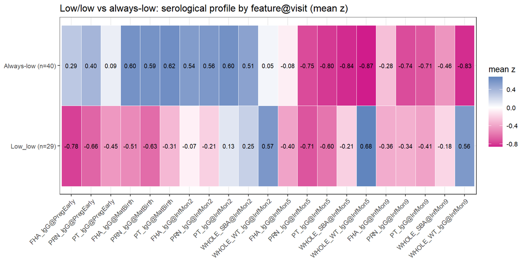

```r
## (E6) side-by-side serological profile, by feature@visit (key level)
m_ll <- prof_long %>% dplyr::filter(subject_accession %in% ll_ids) %>%
  dplyr::group_by(key) %>% dplyr::summarize(low_low = mean(z, na.rm = TRUE), .groups = "drop")
m_al <- prof_long %>% dplyr::filter(subject_accession %in% al_ids) %>%
  dplyr::group_by(key) %>% dplyr::summarize(always_low = mean(z, na.rm = TRUE), .groups = "drop")
diff_key <- dplyr::full_join(m_ll, m_al, by = "key") %>%
  dplyr::mutate(diff = always_low - low_low)
diff_key$visit <- sub("^.*@", "", diff_key$key)
diff_key$assay <- sub("@.*$", "", diff_key$key)

## heatmap (two rows) ordered by visit then assay
vord <- c("PregEarly", "MatBirth", "InfMon2", "InfMon5", "InfMon9")
ko   <- diff_key[order(match(diff_key$visit, vord), diff_key$assay), ]
two_hm <- dplyr::bind_rows(
  data.frame(grp = sprintf("Low_low (n=%d)", length(ll_ids)),
             assay = ko$key, mean_z = ko$low_low, stringsAsFactors = FALSE),
  data.frame(grp = sprintf("Always-low (n=%d)", length(al_ids)),
             assay = ko$key, mean_z = ko$always_low, stringsAsFactors = FALSE))
two_hm$assay <- factor(two_hm$assay, levels = ko$key)
grp_lv <- c(sprintf("Low_low (n=%d)", length(ll_ids)),
            sprintf("Always-low (n=%d)", length(al_ids)))
print(profile_heatmap(two_hm,
      "Low/low vs always-low: serological profile by feature@visit (mean z)",
      grp_levels = grp_lv))
```

```r
diff_disp <- diff_key %>%
  dplyr::mutate(low_low = round(low_low, 2), always_low = round(always_low, 2),
                diff = round(diff, 2)) %>%
  dplyr::arrange(dplyr::desc(abs(diff))) %>%
  dplyr::select(key, low_low, always_low, diff)
print(knitr::kable(utils::head(diff_disp, 14),
      caption = paste0("Table E6. Mean z per feature@visit for low/low vs always-low, ",
                       "and the difference (always-low minus low/low), sorted by ",
                       "|difference|. Positive = always-low sits higher.")))
```

Table E6. Mean z per feature@visit for low/low vs always-low, and the difference (always-low minus low/low), sorted by |difference|. Positive = always-low sits higher.

| key | low_low | always_low | diff |
| --- | --- | --- | --- |
| WHOLE_WT_IgG@InfMon5 | 0.68 | -0.87 | -1.54 |
| WHOLE_WT_IgG@InfMon9 | 0.56 | -0.83 | -1.39 |
| PRN_IgG@MatBirth | -0.63 | 0.59 | 1.23 |
| FHA_IgG@MatBirth | -0.51 | 0.60 | 1.10 |
| FHA_IgG@PregEarly | -0.78 | 0.29 | 1.08 |
| PRN_IgG@PregEarly | -0.66 | 0.40 | 1.05 |
| PT_IgG@MatBirth | -0.31 | 0.62 | 0.93 |
| PRN_IgG@InfMon2 | -0.21 | 0.56 | 0.77 |
| WHOLE_SBA@InfMon5 | -0.21 | -0.84 | -0.63 |
| FHA_IgG@InfMon2 | -0.07 | 0.54 | 0.61 |
| PT_IgG@PregEarly | -0.45 | 0.09 | 0.54 |
| WHOLE_WT_IgG@InfMon2 | 0.57 | 0.05 | -0.51 |
| PT_IgG@InfMon2 | 0.13 | 0.60 | 0.47 |
| PRN_IgG@InfMon9 | -0.34 | -0.74 | -0.40 |

```r
## (E7) arm mix + combined scores
mat_arm_of <- function(ids) mat_subject$arm_name[match(ids, mat_subject$subject_accession)]
grp_row <- function(ids, label) {
  d <- link %>% dplyr::filter(subject_accession %in% ids)
  data.frame(group = label, n = length(ids),
             pct_TT_mothers = round(100 * mean(mat_arm_of(ids) == "TT", na.rm = TRUE), 0),
             mean_maternal_z = round(mean(d$maternal_z, na.rm = TRUE), 2),
             mean_infant_z   = round(mean(d$infant_z,   na.rm = TRUE), 2),
             stringsAsFactors = FALSE)
}
cmp_tab <- dplyr::bind_rows(grp_row(ll_ids, "Low_low"),
                            grp_row(al_ids, "Always-low"))
print(knitr::kable(cmp_tab,
      caption = "Table E7. Low/low vs always-low: % TT mothers, and mean combined maternal / infant scores."))
```

Table E7. Low/low vs always-low: % TT mothers, and mean combined maternal / infant scores.

| group | n | pct_TT_mothers | mean_maternal_z | mean_infant_z |
| --- | --- | --- | --- | --- |
| Low_low | 29 | 48 | -0.6 | -0.26 |
| Always-low | 40 | 22 | 0.4 | -0.27 |

```r
cat(sprintf(paste0(
  "\n\n**Interpretation.** Always-low is defined purely on the infant's own responses ",
  "(Low on all %d single-assay panels); low/low additionally requires a *low maternal* ",
  "responder. They overlap in %d subjects but are not the same: always-low also contains ",
  "infants of strong-responder mothers (the blunted high-maternal -> low-infant case), so ",
  "the always-low group should carry a **higher maternal-visit signal** (look for positive ",
  "differences on the PregEarly / MatBirth PT_IgG and PRN_IgG keys in Table E6) and a larger ",
  "TdaP share (Table E7) than low/low. Low/low subjects lack the maternal head-start: they ",
  "are low on both the maternal-visit antigens *and* the infant responses -- a global deficit ",
  "rather than a blunting of transferred antibody. In short, the two groups agree on the ",
  "infant being low, but differ on **why**: always-low mixes 'never made it' with 'had it and ",
  "lost it', while low/low isolates 'never had it'.\n\n"),
  n_sf, length(both)))
```

[output not shown]

```r
n_hi_mat <- sum(mat_subject$universal_high, na.rm = TRUE)
n_lo_mat <- sum(mat_subject$universal_low,  na.rm = TRUE)
n_hi_inf <- sum(inf_subject$universal_high, na.rm = TRUE)
n_lo_inf <- sum(inf_subject$universal_low,  na.rm = TRUE)

cat("## Verdict on Q6\n\n")
```

## Verdict on Q6

```r
cat(sprintf(paste0(
  "- **Stage A (maternal):** %d high and %d low universal maternal responders up to MatBirth.\n",
  "- **Stage B (infant):** %d high and %d low universal infant responders across %s.\n",
  "- **Stage C (linkage):** read Table C1 with the maternal-vs-infant score correlation and the trajectory plot. ",
  "A positive correlation with high-maternal subgroups starting high at the **%s** baseline is the transplacental signal; ",
  "whether the curves stay separated or converge at InfMon5/InfMon9 shows how much the maternal advantage persists once the infant's own priming takes over. ",
  "Low infant responders whose mothers were high responders are the loss-of-transfer cases to flag; low-into-low pairs are the consistent non-responders.\n\n"),
  n_hi_mat, n_lo_mat, n_hi_inf, n_lo_inf,
  paste(INF_VIS, collapse = " -> "), params$infant_baseline))
```

- **Stage A (maternal):** 66 high and 67 low universal maternal responders up to MatBirth.
- **Stage B (infant):** 32 high and 44 low universal infant responders across InfMon2 -> InfMon5 -> InfMon9.
- **Stage C (linkage):** read Table C1 with the maternal-vs-infant score correlation and the trajectory plot. A positive correlation with high-maternal subgroups starting high at the **InfMon2** baseline is the transplacental signal; whether the curves stay separated or converge at InfMon5/InfMon9 shows how much the maternal advantage persists once the infant’s own priming takes over. Low infant responders whose mothers were high responders are the loss-of-transfer cases to flag; low-into-low pairs are the consistent non-responders.

```r
cat(sprintf(paste0(
  "- **Stage B2 (single-assay):** responder subgroups detected separately on %s.\n",
  "- **Stage B3 (concordance):** Table B3-1 / the kappa heatmap show how far those ",
  "single-assay Low/High calls agree across antigens; the mixed-count is the antigen-specific share.\n",
  "- **Stage D (low/low profile):** %d subjects are low on both axes; Tables D3-D6 ",
  "show how their serological profile and arm composition differ, and Table D7 decomposes ",
  "the combined low/low label into the per-assay signals that drive it.\n",
  "- **Stage E (pan-assay classes):** always-high / always-low / mixed classes are profiled, ",
  "and the concordance-defined always-low group is contrasted with the linkage-defined low/low ",
  "group (Tables E5-E7) -- the two 'low' constructions overlap but differ in maternal contribution.\n\n"),
  paste(params$single_feature_subgroups, collapse = ", "),
  sum(link$link_class == "Low_Low", na.rm = TRUE)))
```

- **Stage B2 (single-assay):** responder subgroups detected separately on PT_IgG, PRN_IgG, WHOLE_SBA, WHOLE_PTNA, WHOLE_WT_IgG.
- **Stage B3 (concordance):** Table B3-1 / the kappa heatmap show how far those single-assay Low/High calls agree across antigens; the mixed-count is the antigen-specific share.
- **Stage D (low/low profile):** 29 subjects are low on both axes; Tables D3-D6 show how their serological profile and arm composition differ, and Table D7 decomposes the combined low/low label into the per-assay signals that drive it.
- **Stage E (pan-assay classes):** always-high / always-low / mixed classes are profiled, and the concordance-defined always-low group is contrasted with the linkage-defined low/low group (Tables E5-E7) – the two ‘low’ constructions overlap but differ in maternal contribution.

# Global Participant Accounting

```r
nt_render(nt, caption = "Participant accounting across this analysis.")
```

Participant accounting across this analysis.

| Section | Stratum | Model | N entered | N used | N dropped | Dropped due to (NA driver) |
| --- | --- | --- | --- | --- | --- | --- |
| Early pregnancy (maternal) | WHOLE_PTNA | assay coverage | NA | 0 | NA | not measured here (by design) |
| Early pregnancy (maternal) | WHOLE_SBA | assay coverage | NA | 0 | NA | not measured here (by design) |
| Early pregnancy (maternal) | WHOLE_WT_IgG | assay coverage | NA | 0 | NA | not measured here (by design) |
| Early pregnancy (maternal) | PRN_IgG | assay coverage | NA | 312 | NA | present |
| Early pregnancy (maternal) | FIM_IgG | assay coverage | NA | 312 | NA | present |
| Early pregnancy (maternal) | PT_IgG | assay coverage | NA | 312 | NA | present |
| At birth (maternal) | WHOLE_PTNA | assay coverage | NA | 0 | NA | not measured here (by design) |
| At birth (maternal) | WHOLE_SBA | assay coverage | NA | 0 | NA | not measured here (by design) |
| At birth (maternal) | WHOLE_WT_IgG | assay coverage | NA | 0 | NA | not measured here (by design) |
| At birth (maternal) | PRN_IgG | assay coverage | NA | 283 | NA | present |
| At birth (maternal) | FIM_IgG | assay coverage | NA | 283 | NA | present |
| At birth (maternal) | PT_IgG | assay coverage | NA | 283 | NA | present |
| InfMon2 (infant baseline) | WHOLE_PTNA | assay coverage | NA | 237 | NA | present |
| InfMon2 (infant baseline) | WHOLE_SBA | assay coverage | NA | 222 | NA | present |
| InfMon2 (infant baseline) | WHOLE_WT_IgG | assay coverage | NA | 223 | NA | present |
| InfMon2 (infant baseline) | PRN_IgG | assay coverage | NA | 287 | NA | present |
| InfMon2 (infant baseline) | FIM_IgG | assay coverage | NA | 287 | NA | present |
| InfMon2 (infant baseline) | PT_IgG | assay coverage | NA | 287 | NA | present |
| InfMon5 (infant) | WHOLE_PTNA | assay coverage | NA | 236 | NA | present |
| InfMon5 (infant) | WHOLE_SBA | assay coverage | NA | 229 | NA | present |
| InfMon5 (infant) | WHOLE_WT_IgG | assay coverage | NA | 221 | NA | present |
| InfMon5 (infant) | PRN_IgG | assay coverage | NA | 281 | NA | present |
| InfMon5 (infant) | FIM_IgG | assay coverage | NA | 281 | NA | present |
| InfMon5 (infant) | PT_IgG | assay coverage | NA | 281 | NA | present |
| InfMon9 (infant) | WHOLE_PTNA | assay coverage | NA | 236 | NA | present |
| InfMon9 (infant) | WHOLE_SBA | assay coverage | NA | 209 | NA | present |
| InfMon9 (infant) | WHOLE_WT_IgG | assay coverage | NA | 222 | NA | present |
| InfMon9 (infant) | PRN_IgG | assay coverage | NA | 306 | NA | present |
| InfMon9 (infant) | FIM_IgG | assay coverage | NA | 306 | NA | present |
| InfMon9 (infant) | PT_IgG | assay coverage | NA | 306 | NA | present |